# DBLP Dataset Analysis - Data Engineering Recruitment Task

**Dataset:** DBLP - a comprehensive bibliographic dataset of computer science publications, maintained by Schloss Dagstuhl. It contains metadata for over 6 million publications including journal articles, conference papers, books, and theses.

**Goal:** Extract as much insight as possible from the dataset - covering publication trends, author behaviour, collaboration networks, venue analysis, and automated topic discovery using both classical NLP and modern language models.

**Approach overview:**

1. Stream-parse the raw XML to handle file size without loading everything into memory
2. Exploratory Data Analysis across multiple dimensions (time, authors, pages, venues, titles)
3. Topic clustering using two text representations: TF-IDF and sentence embeddings
4. Semantic search engine over paper titles using dense vector retrieval
5. RAG pipeline: natural language Q&A grounded in retrieved DBLP papers, powered by local LLMs via Ollama
6. Publication Type Classification: a supervised prediction

| # | Section | Description |
| --- | --- | --- |
| 1 | Getting Familiar with the Dataset | XML schema exploration, structural scan |
| 2 | Final Data Parse | Targeted parse of 1M records |
| 3 | Exploratory Data Analysis | EDA across 5 dimensions |
| 4 | Topic Discovery and Clustering | TF-IDF vs embeddings, KMeans, UMAP |
| 5 | Semantic Search: Paper Recommendation System | Dense retrieval over 1M titles |
| 6 | RAG: Research Assistant | Grounded Q&A with local LLM |
| 7 | Publication Type Classification | ML models predicting record type from title |
| 8 | Conclusions | Key findings, limitations |

# Environment Setup

To fully reproduce the environment and run this notebook, please follow the steps below:

#### Python Dependencies

Install all required Python packages using the provided `requirements.txt` file. Run this command in your terminal: `pip install -r requirements.txt`

#### Local LLM Setup (Ollama)

This project utilizes a local Large Language Model for semantic search. You need to have Ollama running in the background.

- Install [Ollama](https://ollama.com/).
- Pull the required model via terminal: `ollama pull llama3.2`
- Ensure the Ollama app is actively running before executing the cells below.

## Imports

```python
import pandas as pd
from lxml import etree
import os
from tqdm.notebook import tqdm
import numpy as np
import re
import seaborn as sns

from collections import Counter
import networkx as nx
from itertools import combinations

import matplotlib.pyplot as plt

import html
import json

from sklearn.feature_extraction.text import TfidfVectorizer
from sklearn.cluster import KMeans
from sklearn.preprocessing import normalize

from sklearn.decomposition import TruncatedSVD
import plotly.express as px
import umap

from sklearn.metrics.pairwise import cosine_similarity
from sentence_transformers import SentenceTransformer

import requests
from sklearn.metrics import silhouette_score

from sklearn.model_selection import train_test_split
from sklearn.pipeline import Pipeline
from sklearn.linear_model import LogisticRegression
from sklearn.naive_bayes import MultinomialNB
from sklearn.svm import LinearSVC
from sklearn.metrics import classification_report
from sklearn.metrics import confusion_matrix, ConfusionMatrixDisplay
```

## Path Configuration

```python
# ---------------------------------------------------------------------------
# Configure the path to the DBLP XML file.
#
# Option 1 (recommended): set the environment variable before launching Jupyter:
#   Linux/macOS : export DBLP_PATH=/path/to/dblp.xml
#   Windows CMD : set DBLP_PATH=C:\path\to\dblp.xml
#
# Option 2 (fallback): place dblp.xml in the same folder as this notebook.
# ---------------------------------------------------------------------------

input_xml = os.environ.get("DBLP_PATH", os.path.join(os.getcwd(), "dblp.xml"))

if not os.path.exists(input_xml):
    raise FileNotFoundError(
        f"DBLP XML not found at '{input_xml}'.\n"
        "Set DBLP_PATH or place dblp.xml next to this notebook."
    )

print(f"Using DBLP file: {input_xml}")
```

```
Using DBLP file: C:\dblp.xml\dblp.xml
```

# 1. Getting Familiar with the Dataset

Before any analysis, it is essential to understand the structure of the data - what record types exist, what fields are available, and how complete the data is. Skipping this step risks building analysis on incorrect assumptions about the schema.

The DBLP XML schema contains 10 top-level record types, each with a different set of child elements. Rather than reading documentation, the structure was explored empirically by sampling records directly from the file.

The first step is a structural scan of the XML - identifying all available tags and inspecting sample records for each type. Results are cached to avoid re-scanning the full file on subsequent runs.

## Available Record Types and Fields

The function below performs a single streaming pass through the XML and collects one sample record per element type, along with all child tags observed across those samples.

```python
def research_dblp_sample(filepath, cache_path="dblp_sample_cache.json"):

    if os.path.exists(cache_path):
        print(f"Loading structure from cache: {cache_path}")
        with open(cache_path, 'r', encoding='utf-8') as f:
            return json.load(f)

    acquired_samples = {}
    elements = {
        "article", "inproceedings", "proceedings", "book", "incollection",
        "phdthesis", "mastersthesis", "www", "person", "data"
    }

    print(f"Starting research for {filepath}...")

    try:
        context = etree.iterparse(filepath, events=("end",), tag=elements, load_dtd=True)
        for event, elem in context:
            tag_name = elem.tag
            if tag_name not in acquired_samples:
                children_tags = list(set([child.tag for child in elem]))
                acquired_samples[tag_name] = {
                    'found_tags': children_tags,
                    'example_title': elem.findtext('title') or "N/A"
                }
                print(f"Discovered structure for <{tag_name}>")

                if len(acquired_samples) == len(elements):
                    break

            elem.clear()
            while elem.getprevious() is not None:
                del elem.getparent()[0]

        del context

    except Exception as e:
        print(f"!!! Process interrupted by error: {e}")
        print("Saving partial results gathered so far...")

    if acquired_samples:
        with open(cache_path, 'w', encoding='utf-8') as f:
            json.dump(acquired_samples, f, indent=4, ensure_ascii=False)
        print(f"Structure (full or partial) saved to {cache_path}")
    else:
        print("No data collected, nothing to save.")

    return acquired_samples

results = research_dblp_sample(input_xml)
results
```

```
Loading structure from cache: dblp_sample_cache.json
```

```
{'mastersthesis': {'found_tags': ['title',
   'author',
   'school',
   'note',
   'ee',
   'year'],
  'example_title': 'Regelbasierte Extraktion und asymmetrische Fusion bibliographischer Informationen.'},
 'book': {'found_tags': ['title',
   'ee',
   'booktitle',
   'editor',
   'year',
   'url',
   'publisher',
   'series',
   'isbn'],
  'example_title': 'Computerization and Work, A Reader on Social Aspects of Computerization'},
 'incollection': {'found_tags': ['title',
   'author',
   'crossref',
   'pages',
   'booktitle',
   'year',
   'ee',
   'url'],
  'example_title': 'Computers in Schools in the USA: A Social History.'},
 'inproceedings': {'found_tags': ['title',
   'author',
   'crossref',
   'pages',
   'booktitle',
   'year',
   'ee',
   'url'],
  'example_title': 'Methods and Tools for Automatic Construction of Ontologies from Textual Resources: A Framework for Comparison and Its Application.'},
 'proceedings': {'found_tags': ['title',
   'ee',
   'booktitle',
   'editor',
   'year',
```

[output cut: 19 more lines]

```
 'article': {'found_tags': ['journal',
   'title',
   'author',
   'month',
   'year',
   'volume'],
  'example_title': 'Interactive Support for Non-Programmers: The Relational and Network Approaches.'},
 'data': {'found_tags': ['title',
   'author',
   'month',
   'ee',
   'year',
   'publisher',
   'stream'],
  'example_title': 'EMG Physical Action Data Set.'}}
```

## Initial Parse - Full Schema Exploration

To understand the scale and distribution of record types, an initial parse loads all 10 element types up to a limit of 4,000,000 records. This is used purely for exploration - to see which fields are populated and which record types dominate the dataset. All 10 record types are loaded initially. Fields that appear only in rare record types or are mostly empty will be dropped in the final, narrower parse.

```python
output_parquet = "dblp_dataset_initial.parquet"
record_limit = 4000000
def parse_dblp_initial(filepath, max_records):
    print(f"Parsing data for {filepath}:")

    data = []
    elements = {
        "article", "inproceedings", "proceedings", "book", "incollection",
                "phdthesis", "mastersthesis", "www", "person", "data"
    }

    context = etree.iterparse(filepath, events=("end",), tag=elements, recover=True)
    bar = tqdm(total=max_records, desc="Downloading records")

    try:
        for event, elem in context:
            record = {"record_type": elem.tag}

            for child in elem:

                if not isinstance(child.tag, str):
                    continue

                tag_name = child.tag
                tag_value = child.text

                if tag_value is None:
                    continue

                if tag_name in record:
                    record[tag_name] = f"{record[tag_name]}, {tag_value}"
                else:
                    record[tag_name] = tag_value

            data.append(record)
            bar.update(1)

            elem.clear()
            while elem.getprevious() is not None:
                del elem.getparent()[0]

            if len(data) >= max_records:
                break

    except Exception as e:
        print(f"The process of parsing data was interrupted by error: {e}")
    finally:
        del context
        bar.close()

    return pd.DataFrame(data)

if os.path.exists(output_parquet):
    print(f"File {output_parquet} already exists. Loading...")
    df = pd.read_parquet(output_parquet)
else:
    df = parse_dblp_initial(input_xml, record_limit)
    print(f"Saving the dataset as a parquet file...")
    df.to_parquet(output_parquet)

print(f"The process is finished! We have {len(df)} records ready for further analysis!")
```

```
File dblp_dataset_initial.parquet already exists. Loading...
The process is finished! We have 4000000 records ready for further analysis!
```

```python
display(df.head())
```

|  | record_type | author | title | year | school | note | ee | editor | booktitle | publisher | ... | volume | number | cite | month | cdrom | chapter | journal | stream | address | publnr |
| --- | --- | --- | --- | --- | --- | --- | --- | --- | --- | --- | --- | --- | --- | --- | --- | --- | --- | --- | --- | --- | --- |
| 0 | mastersthesis | Oliver Hoffmann 0002 | Regelbasierte Extraktion und asymmetrische Fus... | 2009 | University of Trier | Diplomarbeit, Universit | http://dblp.uni-trier.de/papers/DiplomarbeitOl... | None | None | None | ... | None | None | None | None | None | None | None | None | None | None |
| 1 | mastersthesis | Rita Ley | Der Einfluss kleiner naturnaher Retentionsma | 2006 | Diplomarbeit, Universit | None | http://dblp.uni-trier.de/papers/DiplomarbeitRi... | None | None | None | ... | None | None | None | None | None | None | None | None | None | None |
| 2 | mastersthesis | Kurt P. Brown | PRPL: A Database Workload Specification Langua... | 1992 | University of Wisconsin-Madison | None | None | None | None | None | ... | None | None | None | None | None | None | None | None | None | None |
| 3 | mastersthesis | Stephan Vollmer | Portierung des DBLP-Systems auf ein relational... | 2006 | Diplomarbeit, Universit | None | http://dbis.uni-trier.de/Diplomanden/Vollmer/v... | None | None | None | ... | None | None | None | None | None | None | None | None | None | None |
| 4 | mastersthesis | Vanessa C. Klaas | Who's Who in the World Wide Web: Approaches to... | 2007 | Diplomarbeit, LMU M | None | http://www.pms.ifi.lmu.de/publikationen/diplom... | None | None | None | ... | None | None | None | None | None | None | None | None | None | None |

5 rows × 25 columns

The initial dataframe reveals a wide schema with many columns, most of which are sparsely populated. This motivates a targeted second parse that focuses only on the most analytically useful fields.

```python
display(df.columns)
```

```
Index(['record_type', 'author', 'title', 'year', 'school', 'note', 'ee',
       'editor', 'booktitle', 'publisher', 'isbn', 'series', 'url', 'pages',
       'crossref', 'volume', 'number', 'cite', 'month', 'cdrom', 'chapter',
       'journal', 'stream', 'address', 'publnr'],
      dtype='object')
```

## Data Quality Assessment

Missing value rates are computed for every column. This guides decisions about which fields are reliable enough to use in analysis and which need imputation or exclusion.

```python
missing_counts = df.isnull().sum()
missing_percentage = (missing_counts / len(df)) * 100

missing_data_report = pd.DataFrame({
    'Missing records (quantity)': missing_counts,
    'Missing (%)': missing_percentage.round(2)
})

missing_data_report = missing_data_report.sort_values(by='Missing (%)', ascending=False)
display(missing_data_report)
```

|  | Missing records (quantity) | Missing (%) |
| --- | --- | --- |
| address | 3999997 | 100.00 |
| chapter | 3999998 | 100.00 |
| publnr | 3999228 | 99.98 |
| note | 3999178 | 99.98 |
| month | 3998441 | 99.96 |
| school | 3996528 | 99.91 |
| cite | 3993601 | 99.84 |
| cdrom | 3991461 | 99.79 |
| number | 3986634 | 99.67 |
| journal | 3985069 | 99.63 |
| series | 3961799 | 99.04 |
| volume | 3952138 | 98.80 |
| editor | 3951001 | 98.78 |
| isbn | 3928734 | 98.22 |
| publisher | 3918741 | 97.97 |
| stream | 3874953 | 96.87 |
| pages | 286852 | 7.17 |
| ee | 153107 | 3.83 |
| crossref | 103274 | 2.58 |
| author | 72435 | 1.81 |
| booktitle | 36072 | 0.90 |
| url | 19838 | 0.50 |
| title | 1792 | 0.04 |
| year | 0 | 0.00 |
| record_type | 0 | 0.00 |

As expected from a bibliographic dataset spanning decades and multiple publication types, many fields are highly sparse. Fields like `isbn`, `series`, and `publisher` are only relevant to a subset of record types and are therefore mostly missing. Core fields (`title`, `authors`, and `year`) are well-populated and will anchor the analysis.

```python
df['record_type'].value_counts()
```

```
record_type
inproceedings    3856429
proceedings        63327
incollection       43106
book               20994
article            14927
phdthesis           1193
www                   17
mastersthesis          7
Name: count, dtype: int64
```

# 2. Final Data Parse

Based on the exploration above, a focused second parse is performed. Only the four most data-rich record types are retained: `inproceedings`, `proceedings`, `book`, and `incollection`. These cover conference papers and book chapters: the most common and analytically meaningful publication formats in CS research. I also added `article` as they are crucial in terms of CS research.

The parser extracts the following fields per record:

- `title` - paper title
- `authors` - comma-separated author list
- `year` - publication year
- `venue` - journal or conference name
- `pages` - page range

Results are saved to Parquet for fast reloading without re-parsing.

As I noticed in the initial parse, the `.dtd` file provided by DBLP is crucial and needs to be passed to the parser to correctly resolve HTML entities in author names (e.g., accented characters like `&auml;` -> `ä`). Without this, non-ASCII names would appear corrupted. After loading, the dataframe is sorted by `year` and `title` to ensure a consistent row order across sessions. Without this, XML parsing and Parquet I/O can return records in different orders, which would cause `sample()` to select different subsets and make clustering results non-reproducible between kernel restarts. The data describes years from 1949 to 2026, but I reduced the timeline up to 2024, because records for 2025 displayed a decrease in the amount of publications, which suggested that the dataset might not be up to date.

```python
output_parquet = "dblp_dataset_final.parquet"
record_limit = 1000000

def parse_dblp_final(filepath, max_records):
    print("Parsing data...")
    records = []
    elements = {"inproceedings", "proceedings", "book", "incollection", "article"}

    context = etree.iterparse(
        filepath,
        events=("end",),
        tag=elements,
        recover=True,
        load_dtd=True,
        resolve_entities=True
    )

    bar = tqdm(total=max_records, desc="Downloading records")

    try:
        for event, elem in context:
            authors = ["".join(a.itertext()).strip() for a in elem.findall('author')]
            authors = [a for a in authors if a]

            record = {
                'title': "".join(elem.find('title').itertext()) if elem.find('title') is not None else None,
                'year': elem.findtext('year'),
                'authors': ", ".join(authors),
                'venue': elem.findtext('journal') or elem.findtext('booktitle'),
                'booktitle': elem.findtext('booktitle'),
                'pages': elem.findtext('pages'),
                'ee': elem.findtext('ee'),
                'crossref': elem.findtext('crossref'),
                'url': elem.findtext('url'),
                'record_type': elem.tag
            }

            records.append(record)
            bar.update(1)

            elem.clear()
            while elem.getprevious() is not None:
                del elem.getparent()[0]

            if len(records) >= max_records:
                break

    except Exception as e:
        print(f"Error: {e}")
    finally:
        del context
        bar.close()

    return pd.DataFrame(records)

if os.path.exists(output_parquet):
    print(f"File {output_parquet} already exists. Loading...")
    df_final = pd.read_parquet(output_parquet)
else:
    df_final = parse_dblp_final(input_xml, record_limit)
    print(f"Saving the dataset as a parquet file...")
    df_final.to_parquet(output_parquet)

df_final = df_final.sort_values(['year', 'title']).reset_index(drop=True)
df_final['year'] = pd.to_numeric(df_final['year'], errors='coerce')
df_final = df_final[df_final['year']<=2024]
print(f"The process is finished! We have {len(df_final)} records ready for further analysis!")
```

```
File dblp_dataset_final.parquet already exists. Loading...
The process is finished! We have 961027 records ready for further analysis!
```

## Missing Data in Final Dataset

```python
df_final['record_type'].value_counts()
```

```
record_type
inproceedings    884139
incollection      41677
book              20582
proceedings       14617
article              12
Name: count, dtype: int64
```

```python
missing_counts = df_final.isnull().sum()
missing_percentage = (missing_counts / len(df_final)) * 100

missing_data_report = pd.DataFrame({
    'Missing records (quantity)': missing_counts,
    'Missing (%)': missing_percentage.round(2)
})

missing_data_report = missing_data_report.sort_values(by='Missing (%)', ascending=False)
display(missing_data_report)
```

|  | Missing records (quantity) | Missing (%) |
| --- | --- | --- |
| pages | 62610 | 6.51 |
| ee | 47252 | 4.92 |
| crossref | 35771 | 3.72 |
| booktitle | 18990 | 1.98 |
| venue | 18978 | 1.97 |
| url | 18248 | 1.90 |
| year | 0 | 0.00 |
| title | 0 | 0.00 |
| authors | 0 | 0.00 |
| record_type | 0 | 0.00 |

# 3. Exploratory Data Analysis

The EDA is structured across five dimensions:

1. **Year** - publication volume over time and growth rates
2. **Authors** - prolific authors, career trajectories, team sizes, collaboration networks
3. **Pages** - publication length distributions and trends
4. **Venue** - most active conferences and journals, cross-dimensional venue profiling
5. **Titles** - keyword frequency trends as a proxy for research topic shifts

Each section combines tabular summaries with visualizations to extract both quantitative facts and qualitative patterns.

```python
# SECTION GUARD 3: run this cell if jumping directly to Section 3

if "df_final" not in globals():
    _parquet = "dblp_dataset_final.parquet"
    if not os.path.exists(_parquet):
        raise FileNotFoundError(
            f"'{_parquet}' not found.\n"
            "Please run Section 2 first to generate the parquet file."
        )
    print("Loading df_final from parquet cache...")
    df_final = pd.read_parquet(_parquet)
    df_final = df_final.sort_values(["year", "title"]).reset_index(drop=True)
    print(f"df_final loaded: {len(df_final):,} records.")
else:
    print("df_final already in memory.")
```

```
df_final already in memory.
```

## Publication Volume Over Time

The year field provides a direct view of how CS research output has changed over decades. Volume trends reflect broader forces: the rise of the internet, the democratization of publishing tools, and the explosion of ML/AI research in the 2010s.

```python
top_years = df_final['year'].value_counts().head(10).reset_index()
top_years.columns = ['Publication Year', 'Record Count']
display(top_years)
```

|  | Publication Year | Record Count |
| --- | --- | --- |
| 0 | 2024 | 54335 |
| 1 | 2023 | 53519 |
| 2 | 2019 | 48359 |
| 3 | 2022 | 46035 |
| 4 | 2018 | 44704 |
| 5 | 2021 | 43824 |
| 6 | 2020 | 42965 |
| 7 | 2013 | 42925 |
| 8 | 2016 | 42201 |
| 9 | 2015 | 41713 |

The top 10 most productive years are listed first, followed by a full time-series plot showing publication counts from 1950 to 2024.

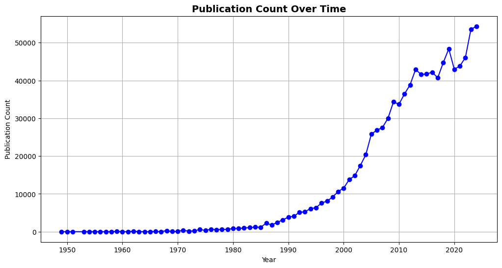

```python
df_years = df_final.dropna(subset=['year']).copy()

yearly_counts = df_years.groupby('year').size()

plt.figure(figsize=(12, 6))
yearly_counts.plot(kind='line', marker='o', color='blue')

plt.title('Publication Count Over Time', fontsize=14, fontweight='bold')
plt.xlabel('Year')
plt.ylabel('Publication Count')
plt.grid(True)
plt.savefig('fig_publication_volume.png', dpi=150, bbox_inches='tight')
plt.show()
```

Publication volume grew slowly and steadily until the mid-1980s, with a notable acceleration starting around 2005. This aligns with the rapid growth of the internet, the rise of open-access publishing, and the proliferation of CS conferences worldwide. The year-over-year percentage change table below quantifies this growth precisely.

```python
yearly_counts = df_years.groupby('year').size().reset_index(name='count')
yearly_counts = yearly_counts.sort_values('year').reset_index(drop=True)
yearly_counts['change_%'] = yearly_counts['count'].pct_change() * 100
yearly_counts['change_%'] = yearly_counts['change_%'].round(2).astype(str) + '%'

recent_changes = yearly_counts.tail(40).sort_values('year', ascending=False)
recent_changes.columns = ['Publication Year', 'Record Count', 'YoY Growth/Decline']

display(recent_changes.reset_index(drop=True))
```

|  | Publication Year | Record Count | YoY Growth/Decline |
| --- | --- | --- | --- |
| 0 | 2024 | 54335 | 1.52% |
| 1 | 2023 | 53519 | 16.26% |
| 2 | 2022 | 46035 | 5.05% |
| 3 | 2021 | 43824 | 2.0% |
| 4 | 2020 | 42965 | -11.15% |
| 5 | 2019 | 48359 | 8.18% |
| 6 | 2018 | 44704 | 9.84% |
| 7 | 2017 | 40699 | -3.56% |
| 8 | 2016 | 42201 | 1.17% |
| 9 | 2015 | 41713 | 0.31% |
| 10 | 2014 | 41584 | -3.12% |
| 11 | 2013 | 42925 | 10.54% |
| 12 | 2012 | 38833 | 6.52% |
| 13 | 2011 | 36455 | 8.13% |
| 14 | 2010 | 33714 | -1.77% |
| 15 | 2009 | 34321 | 14.51% |
| 16 | 2008 | 29971 | 8.87% |
| 17 | 2007 | 27528 | 2.53% |
| 18 | 2006 | 26850 | 4.07% |
| 19 | 2005 | 25801 | 26.79% |
| 20 | 2004 | 20349 | 16.37% |
| 21 | 2003 | 17486 | 18.11% |
| 22 | 2002 | 14805 | 7.45% |
| 23 | 2001 | 13778 | 19.51% |
| 24 | 2000 | 11529 | 8.57% |
| 25 | 1999 | 10619 | 15.95% |
| 26 | 1998 | 9158 | 13.31% |
| 27 | 1997 | 8082 | 6.47% |
| 28 | 1996 | 7591 | 19.68% |
| 29 | 1995 | 6343 | 3.85% |
| 30 | 1994 | 6108 | 16.17% |
| 31 | 1993 | 5258 | 2.56% |
| 32 | 1992 | 5127 | 25.63% |
| 33 | 1991 | 4081 | 6.11% |
| 34 | 1990 | 3846 | 22.91% |
| 35 | 1989 | 3129 | 26.78% |
| 36 | 1988 | 2468 | 38.26% |
| 37 | 1987 | 1785 | -20.74% |
| 38 | 1986 | 2252 | 90.69% |
| 39 | 1985 | 1181 | -1.67% |

## Author Analysis

Author data in DBLP is rich but requires careful preprocessing. The dataset includes researchers from around the world, meaning many names contain non-ASCII characters that must be decoded from HTML entities. Additionally, DBLP disambiguates authors with the same name by appending a numeric suffix (e.g., "Wei Wang 0002"). These suffixes are intentionally preserved in this analysis - removing them caused incorrect publication counts by merging distinct researchers into a single identity. Each disambiguated variant is treated as a separate author, which is consistent with DBLP's own data model where each suffix represents a uniquely identified person.

This section covers:

- Most prolific authors by total publication count
- Career trajectories of top authors over time
- Trends in team size (authors per paper)
- Pairwise collaboration frequency
- A graph-based collaboration network

```python
def clean_author_name(name):
    if not isinstance(name, str):
        return name

    name = html.unescape(name)

    return name.strip()

df_final['authors_clean'] = df_final['authors'].apply(
    lambda x: ", ".join([clean_author_name(a) for a in str(x).split(',')]) if pd.notnull(x) else x
)

df_authors = df_final[df_final['authors_clean'].str.strip() != ''].copy()
df_authors['authors_clean_list'] = df_authors['authors_clean'].str.split(', ')

df_exploded = df_authors.explode('authors_clean_list')

df_exploded = df_exploded[df_exploded['authors_clean_list'].str.strip() != '']

top_authors = df_exploded['authors_clean_list'].value_counts().head(10).reset_index()
top_authors.columns = ['Author', 'Publication Count']

display(top_authors)
```

|  | Author | Publication Count |
| --- | --- | --- |
| 0 | H. Vincent Poor | 385 |
| 1 | Karl Henrik Johansson | 328 |
| 2 | Wen Gao 0001 | 326 |
| 3 | Thomas S. Huang | 316 |
| 4 | Luca Benini | 315 |
| 5 | Miroslav Krstic | 311 |
| 6 | Rolf Drechsler | 281 |
| 7 | Hermann Ney | 277 |
| 8 | Aggelos K. Katsaggelos | 269 |
| 9 | Tamer Basar | 268 |

Author names are decoded from HTML entities using Python's `html.unescape()` and then split into individual names. Each paper is exploded into one row per author to enable per-author aggregations.

### Author Career Analysis

For each author, career metrics are derived from the data: debut year (first publication), most recent publication year, total paper count, and career length. This allows comparison of how long top researchers have been active and how their output has evolved over time.

```python
df_career_base = df_exploded.dropna(subset=['year']).copy()
df_career_base['year'] = pd.to_numeric(df_career_base['year'], errors='coerce')
df_career_base = df_career_base.dropna(subset=['year'])
df_career_base['year'] = df_career_base['year'].astype(int)

author_careers = df_career_base.groupby('authors_clean_list')['year'].agg(['min', 'max', 'count']).reset_index()
author_careers.columns = ['author', 'debut_year', 'last_year', 'total_papers']
author_careers['career_length'] = author_careers['last_year'] - author_careers['debut_year']

debuts_per_year = author_careers.groupby('debut_year').size().reset_index(name='new_authors')

display(author_careers.sort_values('total_papers', ascending=False).head(10))
display(debuts_per_year.sort_values('debut_year', ascending=False).head(10))
```

|  | author | debut_year | last_year | total_papers | career_length |
| --- | --- | --- | --- | --- | --- |
| 303058 | H. Vincent Poor | 1994 | 2024 | 385 | 30 |
| 458623 | Karl Henrik Johansson | 2000 | 2024 | 328 | 24 |
| 920494 | Wen Gao 0001 | 1995 | 2024 | 326 | 29 |
| 868908 | Thomas S. Huang | 1977 | 2020 | 316 | 43 |
| 518075 | Luca Benini | 1996 | 2024 | 315 | 28 |
| 607458 | Miroslav Krstic | 2000 | 2024 | 311 | 24 |
| 743945 | Rolf Drechsler | 1992 | 2024 | 281 | 32 |
| 325304 | Hermann Ney | 1978 | 2024 | 277 | 46 |
| 15164 | Aggelos K. Katsaggelos | 1983 | 2024 | 269 | 41 |
| 855113 | Tamer Basar | 2000 | 2024 | 268 | 24 |

|  | debut_year | new_authors |
| --- | --- | --- |
| 74 | 2024 | 67689 |
| 73 | 2023 | 66421 |
| 72 | 2022 | 54388 |
| 71 | 2021 | 52083 |
| 70 | 2020 | 48493 |
| 69 | 2019 | 54308 |
| 68 | 2018 | 49317 |
| 67 | 2017 | 41654 |
| 66 | 2016 | 43015 |
| 65 | 2015 | 42138 |

The five most prolific authors are selected and their annual publication counts are plotted as time series - revealing whether their productivity is consistent, accelerating, or declining.

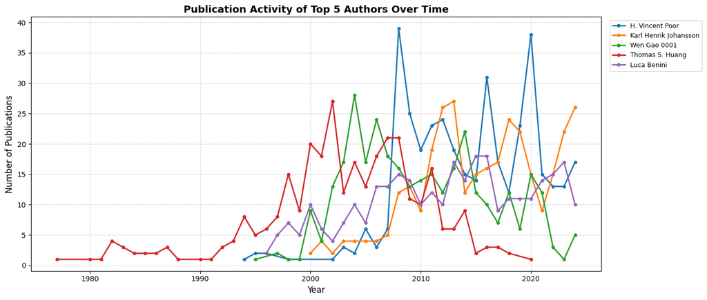

```python
top_n = 5
top_author_names = author_careers.sort_values('total_papers', ascending=False).head(top_n)['author'].tolist()

df_author_year = df_career_base[df_career_base['authors_clean_list'].isin(top_author_names)]
df_author_year = df_author_year.groupby(['year', 'authors_clean_list']).size().reset_index(name='papers')

plt.figure(figsize=(14, 6))

for author in top_author_names:
    data = df_author_year[df_author_year['authors_clean_list'] == author]
    plt.plot(data['year'], data['papers'], marker='o', linewidth=2, label=author, markersize=4)

plt.title(f'Publication Activity of Top {top_n} Authors Over Time', fontsize=14, fontweight='bold')
plt.xlabel('Year', fontsize=12)
plt.ylabel('Number of Publications', fontsize=12)
plt.legend(bbox_to_anchor=(1.01, 1), loc='upper left', fontsize=9)
plt.grid(True, linestyle='--', alpha=0.5)
plt.tight_layout()
plt.savefig('fig_author_careers.png', dpi=150, bbox_inches='tight')
plt.show()
```

### Team Size Trends

Academic publishing has shifted significantly toward collaborative work over the past four decades. This section measures the average number of authors per paper by year - a proxy for how research collaboration norms have changed across the field.

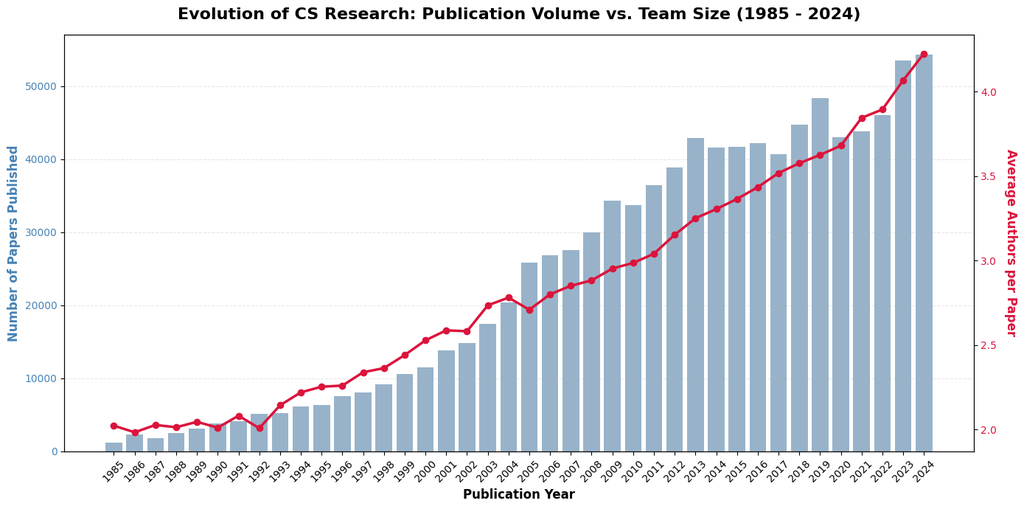

```python
df_trend = df_final.dropna(subset=['year', 'authors_clean']).copy()

df_trend['year'] = pd.to_numeric(df_trend['year'], errors='coerce')
df_trend = df_trend.dropna(subset=['year'])
df_trend['year'] = df_trend['year'].astype(int)

df_trend = df_trend[df_trend['year'] >= 1985]

df_trend['author_count'] = df_trend['authors_clean'].str.count(',') + 1

yearly_stats = df_trend.groupby('year').agg(
    avg_authors=('author_count', 'mean'),
    paper_count=('author_count', 'count')
).reset_index()

fig, ax1 = plt.subplots(figsize=(14, 7))

sns.barplot(
    data=yearly_stats,
    x='year',
    y='paper_count',
    color='steelblue',
    alpha=0.6,
    ax=ax1
)

ax1.set_xlabel('Publication Year', fontsize=12, fontweight='bold')
ax1.set_ylabel('Number of Papers Published', fontsize=12, color='steelblue', fontweight='bold')
ax1.tick_params(axis='y', labelcolor='steelblue')
ax1.tick_params(axis='x', rotation=45)
ax1.grid(True, linestyle='--', alpha=0.3, axis='y')

ax2 = ax1.twinx()

x_positions = range(len(yearly_stats))

ax2.plot(
    x_positions,
    yearly_stats['avg_authors'],
    color='crimson',
    marker='o',
    linewidth=2.5,
    markersize=6
)

ax2.set_ylabel('Average Authors per Paper', fontsize=12, color='crimson', fontweight='bold', rotation=270, labelpad=20)
ax2.tick_params(axis='y', labelcolor='crimson')

plt.title('Evolution of CS Research: Publication Volume vs. Team Size (1985 - 2024)', fontsize=16, fontweight='bold', pad=15)

plt.tight_layout()
plt.savefig('fig_teamsize.png', dpi=150, bbox_inches='tight')
plt.show()
```

Author count per paper is computed by counting commas in the cleaned author string. The result is plotted alongside total publication volume to show whether the growth in publications correlates with growth in team size.

### Author Collaboration Analysis

Beyond team size, it is interesting to identify specific author pairs who have co-authored frequently. High-frequency pairs reveal long-term research partnerships or institutional collaborations.

```python
pair_counts = Counter()

for authors_str in df_final['authors_clean'].dropna():
    authors_list = sorted([a.strip() for a in authors_str.split(',')])
    if len(authors_list) > 1:
        pairs = combinations(authors_list, 2)
        pair_counts.update(pairs)

top_pairs = pair_counts.most_common(25)

top_collabs = pd.DataFrame(top_pairs, columns=['Pair', 'Joint_Papers'])
top_collabs[['Author 1', 'Author 2']] = pd.DataFrame(top_collabs['Pair'].tolist(), index=top_collabs.index)

display(top_collabs[['Author 1', 'Author 2', 'Joint_Papers']])
```

|  | Author 1 | Author 2 | Joint_Papers |
| --- | --- | --- | --- |
| 0 | Miki Haseyama | Takahiro Ogawa 0001 | 122 |
| 1 | Olga Kosheleva | Vladik Kreinovich | 103 |
| 2 | David T. Blaauw | Dennis Sylvester | 90 |
| 3 | Shiguang Shan | Xilin Chen 0001 | 89 |
| 4 | Dong-Seong Kim 0002 | Jae-Min Lee 0001 | 86 |
| 5 | Leonard Barolli | Makoto Ikeda | 85 |
| 6 | Nicolas K. Fontaine | Roland Ryf | 85 |
| 7 | Oscar Castillo 0001 | Patricia Melin | 83 |
| 8 | Ramon Casellas | Ricardo Martínez 0001 | 83 |
| 9 | Enrico Macii | Massimo Poncino | 82 |
| 10 | Eric Rogers | Krzysztof Galkowski | 82 |
| 11 | Maosong Sun 0001 | Zhiyuan Liu 0001 | 82 |
| 12 | Ramon Casellas | Raul Muñoz 0001 | 81 |
| 13 | Anastasios Tefas | Ioannis Pitas | 79 |
| 14 | Ramon Casellas | Ricard Vilalta | 79 |
| 15 | Raul Muñoz 0001 | Ricard Vilalta | 78 |
| 16 | Ricard Vilalta | Ricardo Martínez 0001 | 77 |
| 17 | Ali Saberi | Anton A. Stoorvogel | 76 |
| 18 | Haoshuo Chen | Nicolas K. Fontaine | 75 |
| 19 | Haoshuo Chen | Roland Ryf | 75 |
| 20 | Jörg Henkel | Muhammad Shafique 0001 | 74 |
| 21 | Jun Zhao 0001 | Kang Liu 0001 | 74 |
| 22 | Siwei Ma 0001 | Wen Gao 0001 | 73 |
| 23 | Dimitra Simeonidou | Reza Nejabati | 73 |
| 24 | Raul Muñoz 0001 | Ricardo Martínez 0001 | 73 |

All possible author pairs within each paper are generated using `itertools.combinations`. Pair frequencies are counted across the full dataset and the top 25 most frequent co-authoring pairs are displayed.

#### Collaboration Network Graph

The pairwise collaboration data is modeled as a graph where nodes are authors and edges connect co-authors. The graph is restricted to the top 50 most prolific authors to keep it interpretable. Node size reflects degree (number of distinct collaborators) and edge weight reflects the number of joint papers.

This visualization reveals clusters of authors who form tight research groups, as well as highly connected "hub" authors who bridge multiple communities.

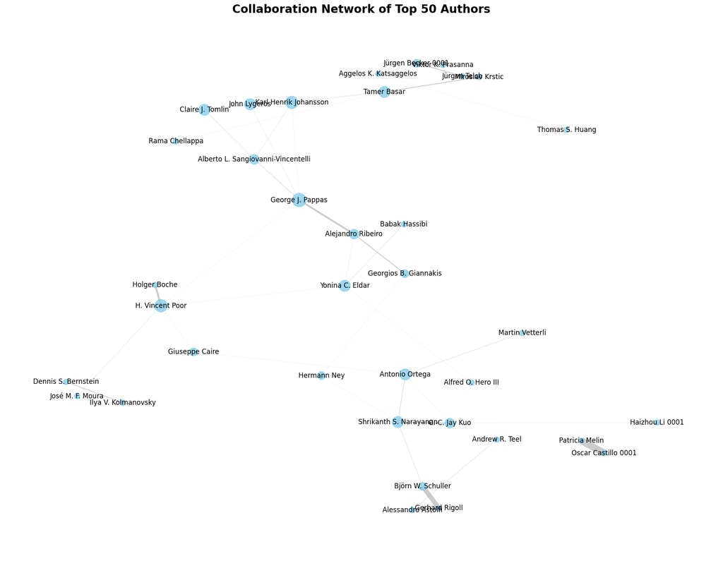

```python
top_50_authors = df_exploded['authors_clean_list'].value_counts().head(50).index.tolist()

valid_paper_indices = df_exploded[df_exploded['authors_clean_list'].isin(top_50_authors)].index.unique()
df_top = df_final.loc[valid_paper_indices].copy()

edges = []
for authors_str in df_top['authors_clean']:
    if pd.notna(authors_str):
        authors_list = [a.strip() for a in authors_str.split(',')]
        filtered_authors = [a for a in authors_list if a in top_50_authors]
        if len(filtered_authors) > 1:
            edges.extend(list(combinations(filtered_authors, 2)))

edge_weights = Counter(tuple(sorted(pair)) for pair in edges)

G = nx.Graph()
for (u, v), w in edge_weights.items():
    G.add_edge(u, v, weight=w)

d = dict(G.degree)
edge_widths = [G[u][v]['weight'] * 0.15 for u, v in G.edges()]

plt.figure(figsize=(18, 14))
pos = nx.spring_layout(G, k=1.3, iterations=100, seed=42)

nx.draw_networkx_nodes(
    G, pos,
    node_size=[v * 100 for v in d.values()],
    node_color='skyblue',
    alpha=0.8
)

nx.draw_networkx_edges(
    G, pos,
    width=edge_widths,
    alpha=0.4,
    edge_color='gray'
)

nx.draw_networkx_labels(
    G, pos,
    font_size=12,
    font_family='sans-serif',
)

plt.title('Collaboration Network of Top 50 Authors', fontsize=20, fontweight='bold')
plt.axis('off')
plt.tight_layout()
plt.savefig('fig_collab_network.png', dpi=150, bbox_inches='tight')
plt.show()
```

## Page Count Analysis

Publication length is a proxy for depth and format. Conference papers are typically capped at 8-12 pages, while journal articles and book chapters can be significantly longer. Analyzing page count distributions reveals the dominant publication formats in the dataset and how norms have shifted over time.

The raw `pages` field in DBLP uses several inconsistent formats (e.g., `10-20`, `10--20`, `12:1-12:8`, roman numerals). A custom parser handles all observed formats and converts them to a unified integer page count.

### Raw Pages Field Inspection

Before computing page counts, the raw `pages` field is inspected to understand what formats appear in the data. DBLP stores page information inconsistently across record types and time periods, requiring a custom parser.

```python
display(df_final['pages'].sample(n=20, random_state=4))
```

```
420266         190-202
196777       3193-3196
350876         105-112
484597         685-686
850244       2182-2193
366008         126-129
10844        1029-1032
484245         163-197
436608            1-16
192734         413-422
154328       1001-1005
779832             1-6
833291         228-238
208936         230-241
559747         620-624
167693       3920-3925
264297    I-XII, 1-322
585003         779-788
688862       2002-2006
567116            None
Name: pages, dtype: object
```

```python
df_pages = df_final.copy()

def classify_page_format(val):
    if pd.isna(val) or val is None or val == "":
        return "Missing (None/NaN)"

    val = str(val).strip().replace(" ", "")

    if re.fullmatch(r'\d+-\d+', val):
        return "Standard Range (e.g., 10-20)"
    elif re.fullmatch(r'\d+', val):
        return "Single Number (e.g., 15)"
    elif re.fullmatch(r'\d+--\d+', val):
        return "Double Dash (e.g., 10--20)"
    elif ":" in val:
        return "Issue Format (e.g., 12:1-12:8)"
    elif re.search(r'[A-Za-z]', val):
        return "Contains Letters/Roman Numerals (e.g., V, 234)"
    else:
        return "Other Custom Format"

df_pages['page_format_type'] = df_final['pages'].apply(classify_page_format)

format_counts = df_pages['page_format_type'].value_counts().reset_index()
format_counts.columns = ['Format Pattern', 'Count']

display(format_counts)

print("\n Samples of complex numbers:")
complex_samples = df_pages[df_pages['page_format_type'] == 'Contains Letters/Roman Numerals (e.g., V, 234)']['pages'].dropna().head(5)
display(complex_samples)
```

|  | Format Pattern | Count |
| --- | --- | --- |
| 0 | Standard Range (e.g., 10-20) | 838320 |
| 1 | Missing (None/NaN) | 62610 |
| 2 | Single Number (e.g., 15) | 26856 |
| 3 | Issue Format (e.g., 12:1-12:8) | 20229 |
| 4 | Contains Letters/Roman Numerals (e.g., V, 234) | 10896 |
| 5 | Other Custom Format | 2116 |

```
 Samples of complex numbers:
```

```
7     I-XII, 1-390
8      I-IV, 1-397
9       I-X, 1-237
11     I-XI, 1-264
13    I-XIV, 1-452
Name: pages, dtype: object
```

```python
df_pages = df_final.copy()

def calculate_page_count(page_string):
    try:
        if not isinstance(page_string, str):
            return np.nan

        s = page_string.replace(" ", "")

        if "," in s:
            s = s.split(",")[-1]

        parts = re.split(r'-+', s)

        if len(parts) == 2:
            start_str = parts[0].split(':')[-1]
            end_str = parts[1].split(':')[-1]

            start_digits = re.sub(r'\D', '', start_str)
            end_digits = re.sub(r'\D', '', end_str)

            if start_digits and end_digits:
                start = int(start_digits)
                end = int(end_digits)

                if end >= start and (end - start) < 1000:
                    return end - start + 1

        elif len(parts) == 1:
            digits = re.sub(r'\D', '', parts[0])
            if digits:
                return 1

        return np.nan
    except:
        return np.nan

print("Parsing page numbers...")
df_pages['page_count'] = df_pages['pages'].apply(calculate_page_count)

df_pages = df_pages.dropna(subset=['page_count']).copy()

print(f"Successfully extracted the length for {len(df_pages)} publications!\n")
```

```
Parsing page numbers...
Successfully extracted the length for 895329 publications!
```

```python
stats = df_pages['page_count'].describe().round(2)
display(pd.DataFrame(stats))
```

|  | page_count |
| --- | --- |
| count | 895329.00 |
| mean | 13.00 |
| std | 45.46 |
| min | 1.00 |
| 25% | 5.00 |
| 50% | 6.00 |
| 75% | 10.00 |
| max | 994.00 |

```python
display(df_pages['page_count'].head(20))
```

```
3     241.0
5     102.0
7     390.0
8     397.0
9     237.0
11    264.0
12    366.0
13    452.0
15    403.0
16    253.0
18    210.0
19    408.0
20      8.0
21      6.0
22      5.0
23      3.0
24      8.0
25      6.0
26      6.0
27      5.0
Name: page_count, dtype: float64
```

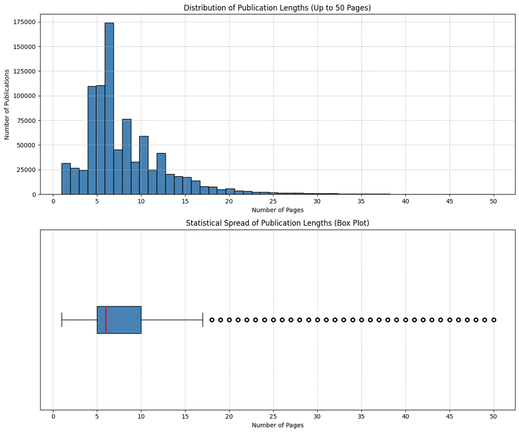

```python
df_plot = df_pages[df_pages['page_count'] <= 50].copy()

fig, (ax1, ax2) = plt.subplots(2, 1, figsize=(12, 10))

ax1.hist(df_plot['page_count'], bins=50, color='steelblue', edgecolor='black')
ax1.set_title('Distribution of Publication Lengths (Up to 50 Pages)')
ax1.set_xlabel('Number of Pages')
ax1.set_ylabel('Number of Publications')
ax1.set_xticks(range(0, 51, 5))
ax1.grid(True, linestyle='--', alpha=0.7)

ax2.boxplot(df_plot['page_count'], vert=False, patch_artist=True,
            boxprops=dict(facecolor='steelblue', color='black'),
            medianprops=dict(color='red', linewidth=2))
ax2.set_title('Statistical Spread of Publication Lengths (Box Plot)')
ax2.set_xlabel('Number of Pages')
ax2.set_xticks(range(0, 51, 5))
ax2.set_yticks([])
ax2.grid(True, linestyle='--', alpha=0.7)

plt.tight_layout()
plt.savefig('fig_page_distribution.png', dpi=150, bbox_inches='tight')
plt.show()
```

### Page Count by Top Author

[figure not shown]

```python
top_20_names = top_authors['Author'].tolist()

df_authors_pages = df_pages.dropna(subset=['authors_clean', 'page_count']).copy()
df_authors_pages = df_authors_pages[df_authors_pages['authors_clean'].str.strip() != ''].copy()

df_authors_pages['authors_list'] = df_authors_pages['authors_clean'].str.split(', ')
df_exploded_pages = df_authors_pages.explode('authors_list')
df_exploded_pages = df_exploded_pages[df_exploded_pages['authors_list'].str.strip() != '']

df_top = df_exploded_pages[df_exploded_pages['authors_list'].isin(top_20_names)].copy()
df_top_plot = df_top[df_top['page_count'] <= 50].copy()

fig, axes = plt.subplots(2, 1, figsize=(10, 8), gridspec_kw={'height_ratios': [1, 2]})

sns.histplot(
    data=df_top_plot,
    x='page_count',
    bins=50,
    color='steelblue',
    ax=axes[0]
)
axes[0].set_title('Overall Distribution of Publication Lengths (Top 20 Authors)', fontsize=12, fontweight='bold')
axes[0].set_xlabel('')
axes[0].set_ylabel('Count', fontsize=11)
axes[0].set_xticks(range(0, 51, 5))
axes[0].grid(True, linestyle='--', alpha=0.6, axis='x')

sns.boxplot(
    data=df_top_plot,
    x='page_count',
    y='authors_list',
    order=top_20_names,
    color='steelblue',
    linewidth=1.5,
    ax=axes[1]
)
axes[1].set_title('Distribution per Author (Box Plot)', fontsize=12, fontweight='bold')
axes[1].set_xlabel('Number of Pages', fontsize=11)
axes[1].set_ylabel('Author', fontsize=11)
axes[1].set_xticks(range(0, 51, 5))
axes[1].grid(True, linestyle='--', alpha=0.6, axis='x')

plt.tight_layout()
plt.show()
```

### Page Count Trends Over Time

Average paper length is tracked from 1985 to 2024. This captures format shifts - for example, whether the rise of conference publishing compressed paper lengths, or whether longer formats have become more common in recent years.

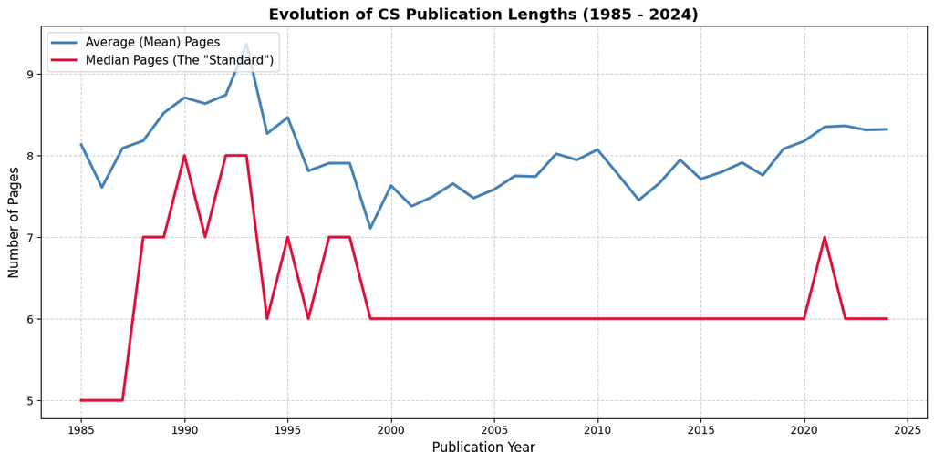

```python
df_len_trend = df_pages.dropna(subset=['year', 'page_count']).copy()

df_len_trend['year'] = pd.to_numeric(df_len_trend['year'], errors='coerce')
df_len_trend = df_len_trend.dropna(subset=['year'])
df_len_trend['year'] = df_len_trend['year'].astype(int)

df_len_trend = df_len_trend[df_len_trend['year'] >= 1985]
df_len_trend = df_len_trend[df_len_trend['page_count'] <= 50]

yearly_len_stats = df_len_trend.groupby('year').agg(
    avg_pages=('page_count', 'mean'),
    median_pages=('page_count', 'median')
).reset_index()

plt.figure(figsize=(12, 6))

sns.lineplot(
    data=yearly_len_stats,
    x='year',
    y='avg_pages',
    label='Average (Mean) Pages',
    color='steelblue',
    linewidth=2.5
)

sns.lineplot(
    data=yearly_len_stats,
    x='year',
    y='median_pages',
    label='Median Pages (The "Standard")',
    color='crimson',
    linewidth=2.5,
)

plt.title('Evolution of CS Publication Lengths (1985 - 2024)', fontsize=14, fontweight='bold')
plt.xlabel('Publication Year', fontsize=12)
plt.ylabel('Number of Pages', fontsize=12)

plt.xticks(range(1985, 2026, 5))
plt.grid(True, linestyle='--', alpha=0.6)
plt.legend(fontsize=11, loc='upper left')

plt.savefig('fig_page_trend.png', dpi=150, bbox_inches='tight')
plt.tight_layout()
plt.show()
```

## Venue Analysis

The `venue` field identifies the conference or journal where each paper was published. Venue analysis reveals which outlets dominate CS publishing, how their volume has changed over time, and how they differ in terms of paper length and team size.

Three views are presented:

- Top venues by total paper count over time
- A scatter plot comparing average pages vs. average team size for top venues
- A heatmap of publication intensity for top authors across top venues

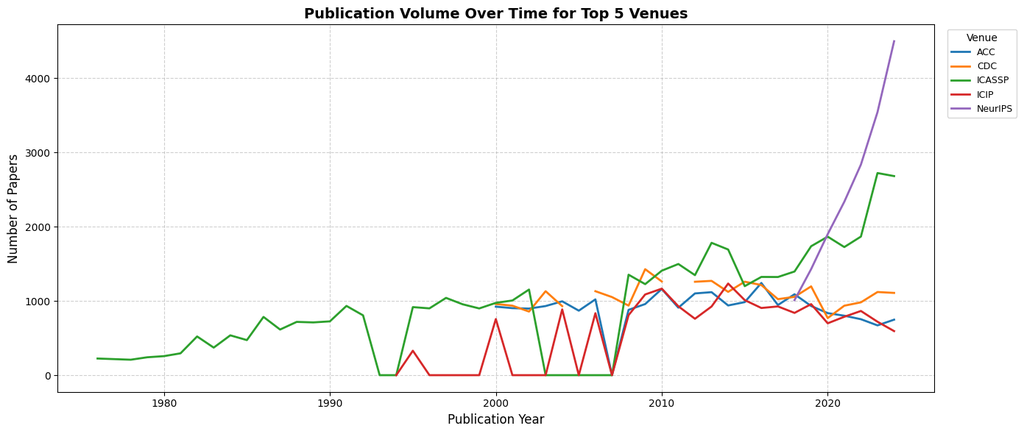

```python
top_venues = df_final.dropna(subset=['venue'])['venue'].value_counts().head(20)

df_venue_year = df_final.dropna(subset=['venue','year']).copy()
df_venue_year['year'] = pd.to_numeric(df_venue_year['year'], errors='coerce')
top5_venues = top_venues.head(5).index.tolist()
df_v5 = df_venue_year[df_venue_year['venue'].isin(top5_venues)].copy()

ax = df_v5.groupby(['year','venue']).size().unstack().plot(
    figsize=(14, 6),
    linewidth=2
)

ax.set_title('Publication Volume Over Time for Top 5 Venues', fontsize=14, fontweight='bold')
ax.set_xlabel('Publication Year', fontsize=12)
ax.set_ylabel('Number of Papers', fontsize=12)
ax.legend(title='Venue', bbox_to_anchor=(1.01, 1), loc='upper left', fontsize=9)
ax.grid(True, linestyle='--', alpha=0.6)

plt.tight_layout()
plt.savefig('fig_venue_trends.png', dpi=150, bbox_inches='tight')
plt.show()
```

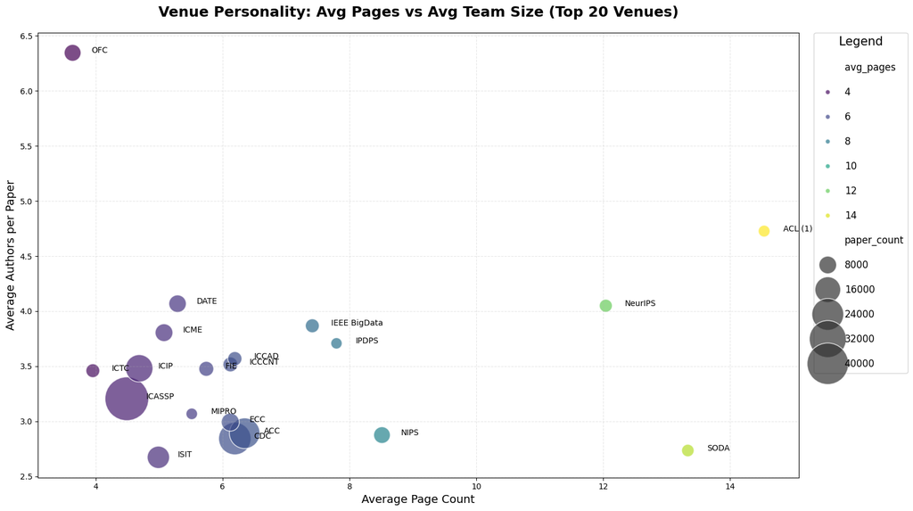

```python
if 'author_count' not in df_pages.columns:
    df_pages['author_count'] = df_pages['authors_clean'].str.count(',') + 1

df_venue = df_pages.dropna(subset=['venue', 'page_count', 'author_count']).copy()

venue_stats = df_venue.groupby('venue').agg(
    paper_count=('title', 'count'),
    avg_pages=('page_count', 'mean'),
    avg_team=('author_count', 'mean')
).reset_index()

top_20_venues = venue_stats.sort_values(by='paper_count', ascending=False).head(20)

plt.figure(figsize=(16, 9))
scatter = sns.scatterplot(
    data=top_20_venues,
    x='avg_pages',
    y='avg_team',
    size='paper_count',
    hue='avg_pages',
    sizes=(200, 3000),
    palette='viridis',
    alpha=0.7
)

for i in range(top_20_venues.shape[0]):
    plt.text(
        top_20_venues.avg_pages.iloc[i] + 0.3,
        top_20_venues.avg_team.iloc[i],
        top_20_venues.venue.iloc[i],
        fontsize=10,
        fontweight='medium'
    )

plt.title('Venue Personality: Avg Pages vs Avg Team Size (Top 20 Venues)', fontsize=18, fontweight='bold', pad=20)
plt.xlabel('Average Page Count', fontsize=14)
plt.ylabel('Average Authors per Paper', fontsize=14)
plt.grid(True, linestyle='--', alpha=0.3)

plt.legend(
    title='Legend',
    title_fontsize=15,
    fontsize=12,
    bbox_to_anchor=(1.02, 1),
    loc='upper left',
    borderaxespad=0,
    labelspacing=1.5
)

plt.tight_layout()
plt.savefig('fig_venue_personality.png', dpi=150, bbox_inches='tight')
plt.show()
```

```python
df_venue = df_pages.dropna(subset=['venue', 'page_count', 'author_count']).copy()

venue_stats = df_venue.groupby('venue').agg(
    paper_count=('title', 'count'),
    avg_pages=('page_count', 'mean'),
).reset_index()

top_venues_table = venue_stats.sort_values(by='paper_count', ascending=False).head(20)

top_venues_table.columns = ['Venue Name', 'Number of Papers', 'Avg Pages']

pd.set_option('display.max_rows', None)
display(top_venues_table.style.format({
    'Avg Pages': '{:.2f}',
}).hide(axis='index'))
```

| Venue Name | Number of Papers | Avg Pages |
| --- | --- | --- |
| ICASSP | 44341 | 4.49 |
| CDC | 24851 | 6.19 |
| ACC | 22223 | 6.35 |
| ICIP | 17977 | 4.69 |
| ISIT | 12260 | 4.99 |
| ECC | 8314 | 6.12 |
| ICME | 8066 | 5.08 |
| DATE | 7850 | 5.29 |
| OFC | 7347 | 3.64 |
| NIPS | 7234 | 8.51 |
| FIE | 5978 | 5.74 |
| ICCCNT | 5919 | 6.12 |
| ICCAD | 5476 | 6.19 |
| IEEE BigData | 5331 | 7.41 |
| ICTC | 5251 | 3.96 |
| NeurIPS | 4771 | 12.04 |
| SODA | 4478 | 13.33 |
| ACL (1) | 4094 | 14.53 |
| MIPRO | 3944 | 5.51 |
| IPDPS | 3856 | 7.80 |

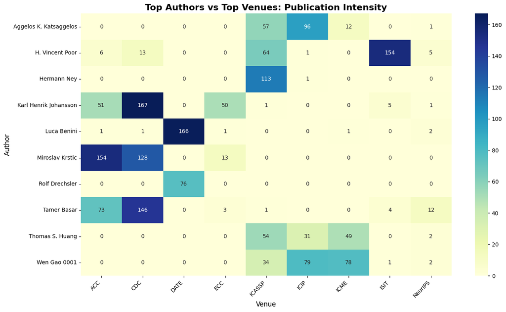

```python
top_author_names = top_authors['Author'].tolist()
top_venue_names = df_final['venue'].value_counts().head(10).index.tolist()

df_matrix_base = df_final[
    df_final['venue'].isin(top_venue_names)
].dropna(subset=['authors_clean', 'venue']).copy()

df_matrix_base['authors_clean_list'] = df_matrix_base['authors_clean'].str.split(', ')
df_matrix_exploded = df_matrix_base.explode('authors_clean_list')
df_matrix_exploded = df_matrix_exploded[
    df_matrix_exploded['authors_clean_list'].isin(top_author_names)
]

pivot_table = df_matrix_exploded.pivot_table(
    index='authors_clean_list',
    columns='venue',
    aggfunc='size',
    fill_value=0
)

plt.figure(figsize=(14, 8))
sns.heatmap(
    pivot_table,
    annot=True,
    fmt='d',
    cmap='YlGnBu'
)

plt.title('Top Authors vs Top Venues: Publication Intensity', fontsize=16, fontweight='bold')
plt.xlabel('Venue', fontsize=12)
plt.ylabel('Author', fontsize=12)
plt.xticks(rotation=45, ha='right')
plt.tight_layout()
plt.savefig('fig_authors_venues_matrix.png', dpi=150, bbox_inches='tight')
plt.show()
```

## Title Keyword Analysis

Paper titles are a compact signal of research topics. By extracting and counting meaningful words from titles over time, it is possible to track which research themes were rising or falling in prominence - without reading a single abstract.

A custom stop-word list removes generic terms (`method`, `approach`, `based`, etc.) that appear across all topics and would otherwise dominate the frequency counts. The remaining words reflect substantive research themes.

```python
df_nlp = df_final.dropna(subset=['year', 'title']).copy()
df_nlp['title'] = df_nlp['title'].apply(
    lambda x: html.unescape(str(x)) if pd.notnull(x) else x
)
df_nlp['year'] = pd.to_numeric(df_nlp['year'], errors='coerce')
df_nlp = df_nlp.dropna(subset=['year'])
df_nlp['year'] = df_nlp['year'].astype(int)

df_nlp = df_nlp[df_nlp['year'] >= 1985]
df_nlp['title_lower'] = df_nlp['title'].str.lower()

stop_words = set([
    'the', 'of', 'and', 'in', 'for', 'a', 'on', 'to', 'with', 'an', 'by', 'from', 'as',
    'based', 'using', 'data', 'approach', 'method', 'methods', 'performance', 'evaluation',
    'via', 'control', 'information', 'time', 'new', 'multi', 'optimization', 'study',
    'learning', 'proposed', 'problem', 'management', 'towards', 'over', 'und', 'system',
    'systems', 'von', 'efficient', 'model', 'analysis', 'algorithm', 'estimation', 'through'
])

def extract_top_buzzwords(titles_series, top_n=3):
    all_words = []
    for title in titles_series:
        words = re.findall(r'\b[a-z]{3,}\b', str(title))
        meaningful_words = [w for w in words if w not in stop_words]
        all_words.extend(meaningful_words)
    if not all_words:
        return "No data"
    most_common = Counter(all_words).most_common(top_n)
    return ", ".join([f"{word} ({count})" for word, count in most_common])

yearly_buzzwords = df_nlp.groupby('year')['title_lower'].apply(extract_top_buzzwords).reset_index()
yearly_buzzwords.columns = ['Publication Year', 'Hot Topics (Count)']

pd.set_option('display.max_rows', None)
display(yearly_buzzwords)
pd.reset_option('display.max_rows')
```

|  | Publication Year | Hot Topics (Count) |
| --- | --- | --- |
| 0 | 1985 | speech (84), design (68), processing (51) |
| 1 | 1986 | speech (173), recognition (108), computer (97) |
| 2 | 1987 | speech (116), parallel (97), adaptive (74) |
| 3 | 1988 | speech (123), design (108), software (104) |
| 4 | 1989 | software (153), parallel (149), speech (135) |
| 5 | 1990 | parallel (195), design (151), algorithms (135) |
| 6 | 1991 | parallel (217), speech (138), algorithms (132) |
| 7 | 1992 | parallel (287), design (220), software (218) |
| 8 | 1993 | parallel (416), design (186), software (173) |
| 9 | 1994 | parallel (320), image (309), design (264) |
| 10 | 1995 | parallel (371), image (290), design (289) |
| 11 | 1996 | image (350), design (316), parallel (279) |
| 12 | 1997 | parallel (459), image (352), design (336) |
| 13 | 1998 | image (442), design (306), web (255) |
| 14 | 1999 | image (513), design (411), web (336) |
| 15 | 2000 | design (555), image (466), adaptive (346) |
| 16 | 2001 | design (627), image (535), adaptive (445) |
| 17 | 2002 | design (639), networks (515), image (465) |
| 18 | 2003 | design (745), networks (670), image (608) |
| 19 | 2004 | networks (1055), design (777), image (574) |
| 20 | 2005 | networks (1195), design (970), web (795) |
| 21 | 2006 | networks (1380), design (984), web (876) |
| 22 | 2007 | networks (1426), design (939), network (907) |
| 23 | 2008 | networks (1843), design (1036), network (974) |
| 24 | 2009 | networks (1793), design (1277), network (1059) |
| 25 | 2010 | networks (1668), design (1200), network (1036) |
| 26 | 2011 | networks (1752), design (1359), network (1152) |
| 27 | 2012 | networks (1938), design (1425), network (1352) |
| 28 | 2013 | networks (2114), design (1496), network (1362) |
| 29 | 2014 | networks (2041), design (1598), detection (1347) |
| 30 | 2015 | networks (2046), detection (1466), design (1393) |
| 31 | 2016 | networks (2139), design (1507), network (1477) |
| 32 | 2017 | networks (2249), network (1669), detection (1616) |
| 33 | 2018 | networks (2546), network (2010), detection (1863) |
| 34 | 2019 | networks (2665), network (2399), detection (2186) |
| 35 | 2020 | networks (2244), network (2221), detection (2055) |
| 36 | 2021 | detection (2297), network (2290), networks (2146) |
| 37 | 2022 | network (2553), detection (2544), networks (2049) |
| 38 | 2023 | detection (3343), network (2678), networks (2279) |
| 39 | 2024 | detection (3368), models (3108), language (2682) |

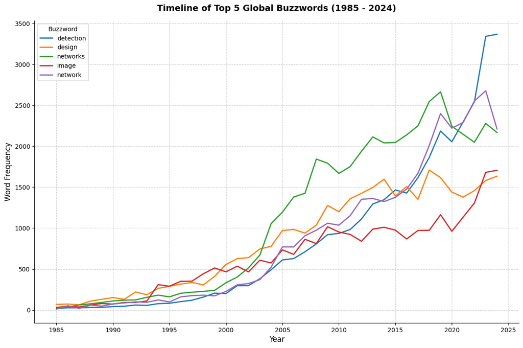

```python
word_data = []
for year, group in df_nlp.groupby('year'):
    all_words = []
    for title in group['title_lower']:
        words = re.findall(r'\b[a-z]{3,}\b', str(title))
        meaningful_words = [w for w in words if w not in stop_words]
        all_words.extend(meaningful_words)
    counts = Counter(all_words)
    for word, count in counts.items():
        word_data.append({'year': year, 'word': word, 'count': count})

df_trends = pd.DataFrame(word_data)

top_global = df_trends.groupby('word')['count'].sum().sort_values(ascending=False).head(5).index.tolist()

plt.figure(figsize=(12, 8))
sns.lineplot(
    data=df_trends[df_trends['word'].isin(top_global)],
    x='year',
    y='count',
    hue='word',
    linewidth=2
)

plt.title('Timeline of Top 5 Global Buzzwords (1985 - 2024)', fontsize=14, fontweight='bold', y=1.02)
plt.xlabel('Year', fontsize=12)
plt.ylabel('Word Frequency', fontsize=12)

plt.grid(True, linestyle='--', alpha=0.6)
plt.legend(title='Buzzword', fontsize=10)
sns.despine()
plt.tight_layout()
plt.show()
```

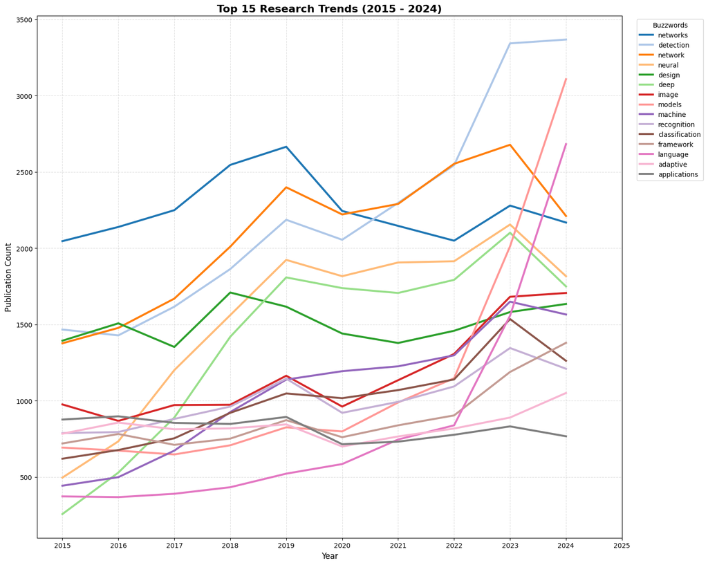

```python
df_recent = df_trends[df_trends['year'] >= 2015]

top_15_recent_global = df_recent.groupby('word')['count'].sum().sort_values(ascending=False).head(15).index.tolist()

plt.figure(figsize=(15, 12))

sns.lineplot(
    data=df_recent[df_recent['word'].isin(top_15_recent_global)],
    x='year',
    y='count',
    hue='word',
    hue_order=top_15_recent_global,
    palette='tab20',
    linewidth=3
)

plt.title('Top 15 Research Trends (2015 - 2024)', fontsize=16, fontweight='bold')
plt.xlabel('Year', fontsize=12)
plt.ylabel('Publication Count', fontsize=12)
plt.xticks(range(2015, 2026))
plt.grid(True, linestyle='--', alpha=0.4)
plt.legend(title='Buzzwords', bbox_to_anchor=(1.02, 1), loc='upper left', fontsize=10)

plt.tight_layout()
plt.savefig('fig_keyword_trends.png', dpi=150, bbox_inches='tight')
plt.show()
```

# 4. Topic Discovery and Clustering

The title keyword analysis in the previous section gave a word-level view of research trends. This section goes further - grouping papers into coherent topic clusters using unsupervised machine learning, then analyzing how those clusters have evolved over time.

**Two text representations are compared:**

|  | TF-IDF + KMeans | Sentence Embeddings + KMeans |
| --- | --- | --- |
| Representation | Sparse word frequency vectors | Dense semantic vectors |
| Meaning-aware | No | Yes |
| Explained variance (50 components) | ~10% | n/a — dense by design |
| Visual cluster separation | Poor | Strong |
| Computation time | Fast | ~10 min |

The comparison is intentional - it demonstrates why the choice of text representation has a decisive impact on clustering quality, especially for short documents like paper titles.

## Data Preparation for Clustering

Clustering is restricted to papers from **2015–2024** to focus on the modern research landscape and avoid noise from older, sparsely-populated years. Titles are first decoded from HTML entities (e.g., `&uuml;` -> `ü`) to handle non-ASCII characters from international authors, then cleaned by lowercasing, removing special characters, and filtering out titles shorter than 4 words. The dataset is capped at **150,000 documents** to keep computation tractable.

```python
df_cluster = df_final.dropna(subset=['title', 'year']).copy()
df_cluster['year'] = pd.to_numeric(df_cluster['year'], errors='coerce')
df_cluster = df_cluster[(df_cluster['year'] >= 2015) & (df_cluster['year'] <= 2024)].dropna(subset=['year'])

def clean_title(text):
    text = str(text).lower().strip()
    text = re.sub(r'[^a-z0-9\s]', ' ', text)
    text = re.sub(r'\s+', ' ', text)
    return text.strip()

df_cluster['title_clean'] = df_cluster['title'].apply(
    lambda x: html.unescape(str(x))
).apply(clean_title)

df_cluster = df_cluster[df_cluster['title_clean'].str.split().str.len() >= 4]

MAX_DOCS = 150_000
if len(df_cluster) > MAX_DOCS:
    df_cluster = df_cluster.sample(n=MAX_DOCS, random_state=42)
df_cluster = df_cluster.reset_index(drop=True)

titles = df_cluster['title_clean'].tolist()
print(f"Titles ready for clustering: {len(titles):,}")
```

```
Titles ready for clustering: 150,000
```

## LLM-Assisted Cluster Labeling

Cluster labels are generated automatically using a local language model (Llama 3.2 via Ollama). The model receives the top 10 TF-IDF keywords for each cluster and returns a concise 2–5 word research-theme label - replacing the need for manual interpretation.

If Ollama is not running, the function falls back to the manually curated labels defined below, so the notebook executes fully in either environment.

To enable LLM labeling: install [Ollama](https://ollama.com) and run in your terminal `ollama pull llama3.2`.

````python
def label_clusters_with_llm(cluster_keywords, fallback_labels=None, cache_path=None):
    if cache_path and os.path.exists(cache_path):
        print(f"Loading cluster labels from cache: {cache_path}")
        with open(cache_path, "r") as f:
            return {int(k): v for k, v in json.load(f).items()}
    keyword_lines = "\n".join(
        f"Cluster {cid}: {', '.join(words)}"
        for cid, words in sorted(cluster_keywords.items())
    )
    prompt = ("Label these computer science research paper clusters.\n"
              "Each cluster has an ID and its top TF-IDF keywords. "
              "Use the keywords to determine the label — do NOT reorder or reassign.\n"
              "Return ONLY a JSON object where each key is the cluster ID (as string) "
              "and the value is a 2-5 word label matching THAT cluster's keywords.\n"
              "No markdown, no explanation.\n\n"
              f"Clusters:\n{keyword_lines}"
             )
    try:
        response = requests.post(
            "http://localhost:11434/api/generate",
            json={"model": "llama3.2", "prompt": prompt, "stream": False},
            timeout=60
        )
        response.raise_for_status()
        raw = response.json()["response"].strip()
        raw = re.sub(r"^```(?:json)?\s*|\s*```$", "", raw, flags=re.DOTALL).strip()
        labels = {int(k): v for k, v in json.loads(raw).items()}
        print("Cluster labels generated by LLM.")
    except Exception as e:
        print(f"Ollama not available ({e}). Using fallback labels.")
        labels = fallback_labels.copy() if fallback_labels is not None else {
            cid: " & ".join(words[:3]).title()
            for cid, words in cluster_keywords.items()
        }

    if fallback_labels:
        for k, v in fallback_labels.items():
            if k not in labels:
                labels[k] = v

    if cache_path:
        with open(cache_path, "w") as f:
            json.dump({str(k): v for k, v in labels.items()}, f, indent=2)
    print("Cluster labels:")
    for cid, label in sorted(labels.items()):
        print(f"  Cluster {cid:>2}: {label}")
    return labels
````

## Approach 1: TF-IDF + KMeans

**TF-IDF** (Term Frequency–Inverse Document Frequency) converts each title into a sparse vector of word importance scores. Words that appear often in a specific title but rarely across the corpus receive high scores — making them good discriminators.

Configuration:

- `max_features=5000` - vocabulary limited to 5,000 most informative words
- `ngram_range=(1,2)` - includes both single words and two-word phrases (e.g., "deep learning")
- `min_df=5` - ignores terms appearing in fewer than 5 documents (noise reduction)
- `max_df=0.85` - ignores terms appearing in more than 85% of documents (too generic)

**Key limitation:** TF-IDF has no notion of meaning. "Deep learning" and "neural networks" are treated as completely unrelated because they share no words.

```python
vectorizer = TfidfVectorizer(
    stop_words='english',
    max_features=5000,
    min_df=5,
    max_df=0.85,
    ngram_range=(1, 2)
)
X_raw = vectorizer.fit_transform(titles)
X_norm = normalize(X_raw, norm='l2')
print(f"TF-IDF matrix shape: {X_norm.shape}")
```

```
TF-IDF matrix shape: (150000, 5000)
```

### Choosing k: The Elbow Method

KMeans requires specifying the number of clusters k in advance. The elbow method tests a range of k values and plots the inertia (total within-cluster sum of squared distances) for each. The optimal k sits at the "elbow" - where adding more clusters gives diminishing improvement. KMeans is run with `n_init=5` for speed at this stage.

```
Testing k=5...
Testing k=8...
Testing k=11...
Testing k=14...
Testing k=17...
Testing k=20...
Testing k=23...
Testing k=26...
Testing k=29...
```

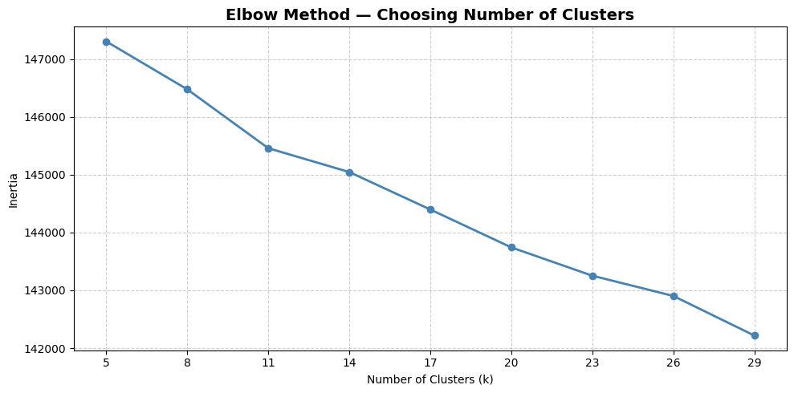

```python
inertia = []
K_range = range(5, 30, 3)

for k in K_range:
    print(f"Testing k={k}...")
    km = KMeans(n_clusters=k, random_state=42, max_iter=100, n_init=5)
    km.fit(X_norm)
    inertia.append(km.inertia_)

plt.figure(figsize=(10, 5))
plt.plot(list(K_range), inertia, marker='o', linewidth=2, color='steelblue')
plt.title('Elbow Method — Choosing Number of Clusters', fontsize=14, fontweight='bold')
plt.xlabel('Number of Clusters (k)')
plt.ylabel('Inertia')
plt.xticks(list(K_range))
plt.grid(True, linestyle='--', alpha=0.6)
plt.tight_layout()
plt.savefig('fig_elbow.png', dpi=150, bbox_inches='tight')
plt.show()
```

No sharp elbow is visible - a common finding for high-dimensional sparse TF-IDF data where cluster boundaries are inherently fuzzy. Three values of k were tested iteratively: 20, 10, and 7 - starting broad to explore the topic space, then progressively merging over-fragmented clusters.

### Exploration Run: k=20

A high k is tested first to capture the full thematic diversity of CS research. With 20 clusters, fine-grained topics emerge but some clusters show low coherence - grouping unrelated papers that share only generic vocabulary like "model", "approach", or "analysis". This is a known artifact of KMeans on sparse TF-IDF.

```python
K=20

km_model = KMeans(n_clusters=K, random_state=42, n_init=10, max_iter=300)
km_model.fit(X_norm)

df_cluster_20 = df_cluster.copy()
df_cluster_20['cluster'] = km_model.labels_
print(f"Clustering done. Documents per cluster:")
print(df_cluster_20['cluster'].value_counts().sort_index())
```

```
Clustering done. Documents per cluster:
cluster
0      8906
1     62620
2      5166
3      5400
4      1774
5      8013
6      1316
7      4889
8      2036
9      2621
10     3860
11     1729
12     5753
13     5189
14     2219
15     5549
16     2812
17     6351
18    10766
19     3031
Name: count, dtype: int64
```

#### Inspecting Cluster Keywords

The top 10 highest-weight TF-IDF terms from each cluster centroid are printed. These are the words that best characterize each cluster and serve as the basis for manual labeling.

```python
feature_names = vectorizer.get_feature_names_out()
cluster_centers = km_model.cluster_centers_

for i in range(km_model.n_clusters):
    top_indices = cluster_centers[i].argsort()[-10:][::-1]
    top_words = [feature_names[j] for j in top_indices]
    print(f"Cluster {i:>2} | Top words: {', '.join(top_words)}")

cluster_keywords_20 = {
    i: [feature_names[j] for j in cluster_centers[i].argsort()[-10:][::-1]]
    for i in range(km_model.n_clusters)
}
```

```
Cluster  0 | Top words: using, design, estimation, multi, image, classification, implementation, algorithm, study, networks
Cluster  1 | Top words: networks, multi, study, information, efficient, image, optimization, models, algorithm, applications
Cluster  2 | Top words: control, systems, predictive, predictive control, based, model, model predictive, optimal, adaptive, optimal control
Cluster  3 | Top words: systems, multi, based, linear, time, cyber, cyber physical, recommender systems, agent systems, physical
Cluster  4 | Top words: computing, edge computing, edge, cloud computing, cloud, based, fog, fog computing, mobile, quantum computing
Cluster  5 | Top words: learning, machine learning, machine, reinforcement, reinforcement learning, using, based, federated, federated learning, using machine
Cluster  6 | Top words: privacy, preserving, privacy preserving, differential privacy, data, differential, protection, privacy protection, security, security privacy
Cluster  7 | Top words: network, neural network, neural, based, convolutional, convolutional neural, using, network based, deep, image
Cluster  8 | Top words: neural networks, neural, networks, convolutional neural, convolutional, deep neural, deep, graph neural, using, graph
Cluster  9 | Top words: deep, deep learning, learning, using deep, deep reinforcement, learning based, based, using, reinforcement, reinforcement learning
Cluster 10 | Top words: approach, based approach, based, using, data, novel, learning, multi, learning approach, novel approach
Cluster 11 | Top words: real time, real, time, using, based, detection, monitoring, data, systems, scheduling
Cluster 12 | Top words: model, language, language models, models, large language, large, based, model based, language model, natural language
Cluster 13 | Top words: detection, based, object detection, using, object, anomaly, anomaly detection, detection using, detection based, network
Cluster 14 | Top words: international, conference, proceedings, international conference, 2023, 2018, 2022, 2019, workshop, 2017
Cluster 15 | Top words: analysis, based, sentiment, sentiment analysis, using, data, comparative analysis, comparative, data analysis, network
Cluster 16 | Top words: performance, performance analysis, high performance, analysis, performance evaluation, high, evaluation, based, using, systems
Cluster 17 | Top words: data, big, big data, data driven, driven, using, based, analytics, mining, data analytics
Cluster 18 | Top words: based, algorithm, image, using, multi, design, recognition, networks, optimization, algorithm based
Cluster 19 | Top words: method, based, method based, using, detection, detection method, based method, method using, novel, multi
```

#### LLM-Assisted Cluster Labeling

The `label_clusters_with_llm` function defined above is called with the top 10 TF-IDF keywords per cluster. Results are cached to `cluster_labels_k20.json` - on subsequent runs the model is skipped and labels are loaded from cache instead.

```python
manual_labels_k20 = label_clusters_with_llm(
    cluster_keywords_20,
    fallback_labels={
        0:  "Image Classification & Algorithm Design",
        1:  "Network Optimization & Applications",
        2:  "Predictive & Adaptive Control Systems",
        3:  "Cyber-Physical & Recommender Systems",
        4:  "Edge, Cloud & Quantum Computing",
        5:  "Machine & Federated Learning",
        6:  "Differential Privacy & Data Security",
        7:  "Convolutional Neural Networks for Images",
        8:  "Deep & Graph Neural Networks",
        9:  "Deep Reinforcement Learning",
        10: "Novel Data & Learning Approaches",
        11: "Real-Time Monitoring & Detection",
        12: "Large Language Models (LLMs)",
        13: "Object & Anomaly Detection Networks",
        14: "Conference Proceedings",
        15: "Sentiment & Comparative Analysis",
        16: "System Performance Evaluation",
        17: "Big Data Analytics & Mining",
        18: "Image Recognition Algorithms",
        19: "Multi-Method Detection Approaches"
    },
    cache_path="cluster_labels_k20.json"
)
```

```
Cluster labels generated by LLM.
Cluster labels:
  Cluster  0: Image Classification
  Cluster  1: Image Optimization
  Cluster  2: Optimal Control
  Cluster  3: Cyber Physical Systems
  Cluster  4: Edge Computing
  Cluster  5: Machine Reinforcement Learning
  Cluster  6: Privacy Protection
  Cluster  7: Convolutional Neural Networks
  Cluster  8: Deep Neural Networks
  Cluster  9: Deep Learning Approach
  Cluster 10: Novel Multi-Method Approach
  Cluster 11: Real Time Systems
  Cluster 12: Large Language Models
  Cluster 13: Object Detection Methods
  Cluster 14: International Conference Proceedings
  Cluster 15: Comparative Data Analysis
  Cluster 16: High Performance Evaluation
  Cluster 17: Big Data Analytics
  Cluster 18: Image Recognition Networks
  Cluster 19: Multi-Method Detection Methods
```

#### Distribution of Papers Across Clusters

A bar chart shows how many papers were assigned to each cluster. Highly unequal distributions can indicate that some clusters are acting as "catch-all" buckets - a sign that k may be too high or the representation too weak.

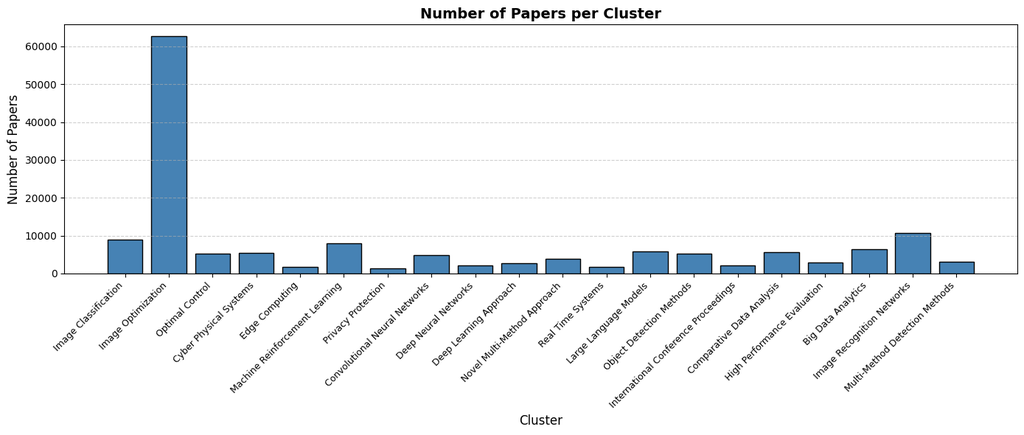

```python
cluster_sizes = df_cluster_20['cluster'].value_counts().reset_index()
cluster_sizes.columns = ['cluster', 'count']
cluster_sizes['label'] = cluster_sizes['cluster'].map(manual_labels_k20)
cluster_sizes = cluster_sizes.sort_values('cluster')

plt.figure(figsize=(14, 6))
plt.bar(cluster_sizes['label'], cluster_sizes['count'], color='steelblue', edgecolor='black')
plt.title('Number of Papers per Cluster', fontsize=14, fontweight='bold')
plt.xlabel('Cluster', fontsize=12)
plt.ylabel('Number of Papers', fontsize=12)
plt.xticks(rotation=45, ha='right', fontsize=9)
plt.grid(True, axis='y', linestyle='--', alpha=0.6)
plt.tight_layout()
plt.show()
```

#### Research Topic Trends Over Time

Each cluster is tracked across years to reveal which research areas are growing, stable, or declining. Only the top 10 clusters by total paper count are shown to keep the chart readable.

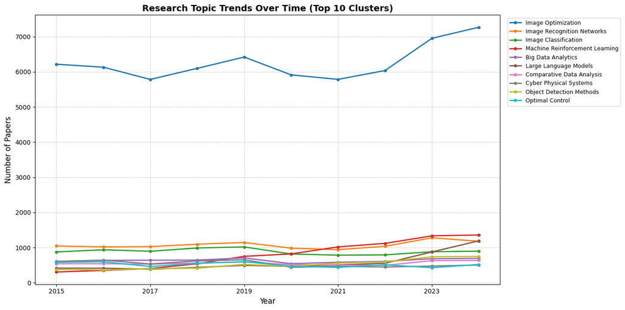

```python
df_trend = df_cluster_20[df_cluster_20['cluster'] != -1].copy()
df_trend['year'] = df_trend['year'].astype(int)
df_trend['cluster_label'] = df_trend['cluster'].map(manual_labels_k20)

trend_df = (
    df_trend
    .groupby(['year', 'cluster_label'])
    .size()
    .reset_index(name='count')
)

top_clusters = (
    trend_df.groupby('cluster_label')['count']
    .sum()
    .nlargest(10)
    .index.tolist()
)

trend_top = trend_df[trend_df['cluster_label'].isin(top_clusters)]

plt.figure(figsize=(14, 7))

for label in top_clusters:
    data = trend_top[trend_top['cluster_label'] == label]
    plt.plot(data['year'], data['count'], marker='o', linewidth=2, markersize=4, label=label)

plt.title('Research Topic Trends Over Time (Top 10 Clusters)', fontsize=14, fontweight='bold')
plt.xlabel('Year', fontsize=12)
plt.ylabel('Number of Papers', fontsize=12)
plt.xticks(range(df_trend['year'].min(), df_trend['year'].max() + 1, 2))
plt.grid(True, linestyle='--', alpha=0.6)
plt.legend(bbox_to_anchor=(1.01, 1), loc='upper left', fontsize=9)
plt.tight_layout()
plt.show()
```

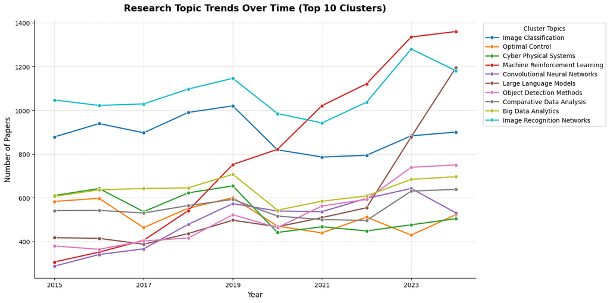

```python
CLUSTER_TO_EXCLUDE = 1
df_trend = df_trend[df_trend['cluster'] != CLUSTER_TO_EXCLUDE]

trend_df = (
    df_trend
    .groupby(['year', 'cluster', 'cluster_label'])
    .size()
    .reset_index(name='count')
)

top_cluster_ids = (
    trend_df.groupby('cluster')['count']
    .sum()
    .nlargest(10)
    .index.tolist()
)

trend_top = trend_df[trend_df['cluster'].isin(top_cluster_ids)]

plt.figure(figsize=(14, 7))

sns.lineplot(
    data=trend_top,
    x='year',
    y='count',
    hue='cluster_label',
    marker='o',
    linewidth=2,
    markersize=6
)

plt.title('Research Topic Trends Over Time (Top 10 Clusters)', fontsize=15, fontweight='bold', y=1.02)
plt.xlabel('Year', fontsize=12)
plt.ylabel('Number of Papers', fontsize=12)

min_year = int(df_trend['year'].min())
max_year = int(df_trend['year'].max())
plt.xticks(range(min_year, max_year + 1, 2))

plt.grid(True, linestyle='--', alpha=0.5)
plt.legend(bbox_to_anchor=(1.01, 1), loc='upper left', fontsize=10, title="Cluster Topics")
sns.despine()
plt.tight_layout()
plt.savefig('fig_topic_trends.png', dpi=150, bbox_inches='tight')
plt.show()
```

The topic trend analysis reveals several distinct patterns in CS research between 2015 and 2024, strongly reflecting industry shifts toward advanced Artificial Intelligence.

### Refinement Run: k=10

```python
K=10

km_model = KMeans(n_clusters=K, random_state=42, n_init=10, max_iter=300)
km_model.fit(X_norm)

df_cluster_10 = df_cluster.copy()
df_cluster_10['cluster'] = km_model.labels_
print(f"Clustering done. Documents per cluster:")
print(df_cluster_10['cluster'].value_counts().sort_index())
```

```
Clustering done. Documents per cluster:
cluster
0    87787
1     3218
2     5889
3    11070
4    14757
5     7687
6     2451
7     6006
8     6872
9     4263
Name: count, dtype: int64
```

#### Cluster Keywords at k=10

```python
feature_names = vectorizer.get_feature_names_out()
cluster_centers = km_model.cluster_centers_

for i in range(km_model.n_clusters):
    top_indices = cluster_centers[i].argsort()[-10:][::-1]
    top_words = [feature_names[j] for j in top_indices]
    print(f"Cluster {i:>2} | Top words: {', '.join(top_words)}")
```

```
Cluster  0 | Top words: using, analysis, model, design, control, networks, time, network, study, approach
Cluster  1 | Top words: models, language, language models, large language, large, using, diffusion models, diffusion, based, learning
Cluster  2 | Top words: detection, based, using, object detection, anomaly, object, anomaly detection, detection using, detection based, network
Cluster  3 | Top words: learning, deep, machine learning, machine, deep learning, reinforcement, reinforcement learning, using, based, learning based
Cluster  4 | Top words: based, model, algorithm, analysis, method, control, using, approach, image, design
Cluster  5 | Top words: data, big, big data, data driven, driven, based, using, analysis, analytics, mining
Cluster  6 | Top words: architecture, memory, based, efficient, using, computing, systems, hybrid, design, software
Cluster  7 | Top words: multi, multi agent, agent, based, learning, multi objective, objective, systems, multi modal, modal
Cluster  8 | Top words: systems, control, time, based, linear, nonlinear, design, recommender systems, linear systems, cyber
Cluster  9 | Top words: neural, neural networks, neural network, networks, network, convolutional neural, convolutional, deep neural, deep, using
```

k=10 produced more coherent clusters than k=20, but several clusters still showed significant topic overlap. A further reduction to k=7 was applied to reach the most distinct and interpretable configuration.

### Final TF-IDF Model: k=7

```python
K=7

km_model = KMeans(n_clusters=K, random_state=42, n_init=10, max_iter=300)
km_model.fit(X_norm)

df_cluster_7 = df_cluster.copy()
df_cluster_7['cluster'] = km_model.labels_
print(f"Clustering done. Documents per cluster:")
print(df_cluster_7['cluster'].value_counts().sort_index())
```

```
Clustering done. Documents per cluster:
cluster
0     5168
1    11771
2    99416
3     4422
4     6081
5     6234
6    16908
Name: count, dtype: int64
```

#### Cluster Keywords at k=7

```python
feature_names = vectorizer.get_feature_names_out()
cluster_centers = km_model.cluster_centers_

for i in range(km_model.n_clusters):
    top_indices = cluster_centers[i].argsort()[-10:][::-1]
    top_words = [feature_names[j] for j in top_indices]
    print(f"Cluster {i:>2} | Top words: {', '.join(top_words)}")

cluster_keywords_7 = {
    i: [feature_names[j] for j in cluster_centers[i].argsort()[-10:][::-1]]
    for i in range(km_model.n_clusters)
}
```

```
Cluster  0 | Top words: models, language, large, language models, large scale, scale, large language, natural language, natural, language model
Cluster  1 | Top words: learning, deep, machine learning, machine, deep learning, reinforcement, reinforcement learning, based, using, learning based
Cluster  2 | Top words: using, data, systems, analysis, control, design, model, time, networks, network
Cluster  3 | Top words: neural, neural networks, neural network, networks, network, convolutional neural, convolutional, deep neural, deep, using
Cluster  4 | Top words: detection, based, using, object detection, anomaly, object, anomaly detection, detection using, detection based, network
Cluster  5 | Top words: multi, multi agent, agent, based, systems, learning, multi objective, objective, multi modal, modal
Cluster  6 | Top words: based, model, analysis, algorithm, control, data, method, approach, using, systems
```

#### LLM-Assisted Cluster Labeling

The same labeling approach is applied to the final k=7 TF-IDF model. Results are cached separately to `cluster_labels_k7.json`.

```python
manual_labels_k7 = label_clusters_with_llm(
    cluster_keywords_7,
    fallback_labels={
        0: "Large Language Models (LLMs)",
        1: "Machine & Reinforcement Learning",
        2: "System Analysis & Control Networks",
        3: "Deep & Convolutional Neural Networks",
        4: "Object & Anomaly Detection",
        5: "Multi-Agent & Multi-Objective Systems",
        6: "General Algorithms & Data Models"
    },
    cache_path="cluster_labels_k7.json"
)
```

```
Cluster labels generated by LLM.
Cluster labels:
  Cluster  0: Large Language Models (LLMs)
  Cluster  1: Machine Learning
  Cluster  2: Data Systems Analysis
  Cluster  3: Neural Networks
  Cluster  4: Object Detection
  Cluster  5: Multi Agent Systems
  Cluster  6: Model Based Control
```

#### Cluster Visualizations

Two visualizations are produced for the final TF-IDF model:

1. **Horizontal bar chart** — paper count per cluster, sorted by size. Reveals the relative prominence of each research theme in the 2015–2024 literature.
2. **UMAP scatter plot** — each paper projected to 2D, colored by cluster assignment. UMAP (Uniform Manifold Approximation and Projection) compresses the high-dimensional. TF-IDF vectors to 2D while trying to preserve neighborhood structure: papers that are similar in high-dimensional space should appear close on the plot. Hover over any point to see the paper title.

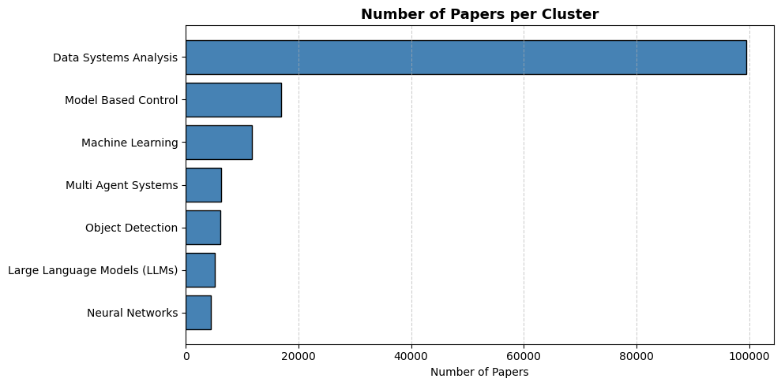

```python
cluster_sizes = df_cluster_7['cluster'].value_counts().reset_index()
cluster_sizes.columns = ['cluster', 'count']
cluster_sizes['label'] = cluster_sizes['cluster'].map(manual_labels_k7)
cluster_sizes = cluster_sizes.sort_values('count', ascending=True)

plt.figure(figsize=(10, 5))
plt.barh(cluster_sizes['label'], cluster_sizes['count'], color='steelblue', edgecolor='black')
plt.title('Number of Papers per Cluster', fontsize=13, fontweight='bold')
plt.xlabel('Number of Papers')
plt.grid(axis='x', linestyle='--', alpha=0.6)
plt.tight_layout()
plt.show()
```

##### Visualization Attempt 1: Raw TF-IDF -> UMAP

UMAP is applied directly to the raw TF-IDF matrix (papers × 5,000 features).

```python
df_cluster_7['cluster_label'] = df_cluster_7['cluster'].map(manual_labels_k7)
reducer = umap.UMAP(n_components=2, random_state=42, n_neighbors=15, min_dist=0.1)
coords = reducer.fit_transform(X_norm)

df_plot = pd.DataFrame({
    'x': coords[:, 0],
    'y': coords[:, 1],
    'cluster': df_cluster_7['cluster_label'],
    'title': df_cluster_7['title']
})
fig = px.scatter(
    df_plot, x='x', y='y', color='cluster',
    hover_data=['title'], opacity=0.6,
    title='TF-IDF Clusters - UMAP Projection',
    width=900, height=650
)
fig.update_traces(marker=dict(size=3))
fig.update_layout(legend=dict(title='Cluster'))
fig.show()
fig.write_html("umap_tfidf_k7.html")
```

[output not shown]

A dimensionality reduction step before UMAP is needed.

##### Visualization Attempt 2: TF-IDF -> LSA -> UMAP

LSA (Latent Semantic Analysis) is applied first to compress 5,000 sparse word features into 50 dense latent topic dimensions. LSA uses TruncatedSVD - a matrix factorization technique that finds directions of maximum variance in the data. It groups co-occurring words together: "neural", "network", and "deep" collapse into a shared latent dimension. UMAP then runs on this denser, lower-dimensional representation.

```
Explained variance: 10.10%
```

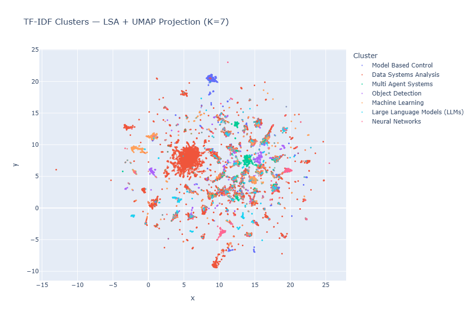

```python
svd = TruncatedSVD(n_components=50, random_state=42)
X_lsa = svd.fit_transform(X_norm)
print(f"Explained variance: {svd.explained_variance_ratio_.sum():.2%}")
reducer = umap.UMAP(
    n_components=2,
    random_state=42,
    n_neighbors=30,
    min_dist=0.0,
    metric='cosine'
)
coords = reducer.fit_transform(X_lsa)
df_plot = pd.DataFrame({
    'x': coords[:, 0],
    'y': coords[:, 1],
    'cluster': df_cluster_7['cluster_label'],
    'title': df_cluster_7['title']
})
fig = px.scatter(
    df_plot, x='x', y='y', color='cluster',
    hover_data=['title'], opacity=0.6,
    title='TF-IDF Clusters — LSA + UMAP Projection (K=7)',
    width=900, height=650
)
fig.update_traces(marker=dict(size=3))
fig.update_layout(legend=dict(title='Cluster'))
fig.show()
fig.write_html("umap_tfidf_lsa_k7.html")
```

The LSA step reduces sparsity but cluster separation in the UMAP projection remains poor. To understand why, the explained variance is measured across a range of component counts.

```python
for n in [50, 100, 200, 300]:
    svd_test = TruncatedSVD(n_components=n, random_state=42)
    svd_test.fit(X_norm)
    print(f"n={n}: {svd_test.explained_variance_ratio_.sum():.2%}")
```

```
n=50: 10.10%
n=100: 15.98%
n=200: 24.72%
n=300: 31.40%
```

The UMAP projection therefore shows substantial cluster overlap - not due to a flaw in the code, but because the bag-of-words representation loses too much information for short texts.

### Silhouette Score

Silhouette score is computed on a random subsample of 5,000 documents (out of 150,000) due to the O(n²) memory cost of the full pairwise distance matrix. Results are cached to `silhouette_results.json` - delete the file to force recomputation.

```
Cache not found. Sampling and calculating Silhouette Scores (K=2 to 30)...
```

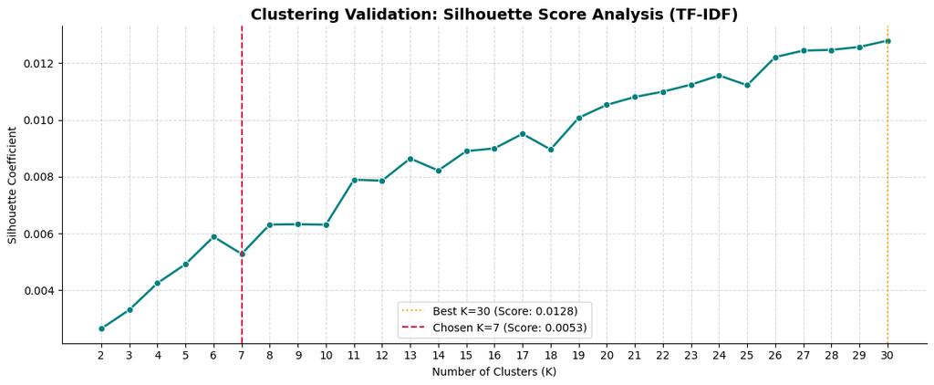

```python
cache_path = "silhouette_results.json"
k_values = list(range(2, 31))
chosen_k = 7
SILHOUETTE_SAMPLE = 5000

if os.path.exists(cache_path):
    print("Loading cached results...")
    with open(cache_path, 'r') as f:
        scores = json.load(f)['scores']
else:
    print("Cache not found. Sampling and calculating Silhouette Scores (K=2 to 30)...")
    np.random.seed(42)
    sample_idx = np.random.choice(X_norm.shape[0], size=SILHOUETTE_SAMPLE, replace=False)
    X_sil = X_norm[sample_idx]

    scores = []
    for k in tqdm(k_values, desc="KMeans Silhouette"):
        labels = KMeans(n_clusters=k, random_state=42, n_init=10).fit_predict(X_sil)
        scores.append(float(silhouette_score(X_sil, labels)))

    with open(cache_path, 'w') as f:
        json.dump({'k_values': k_values, 'scores': scores}, f)

best_score = max(scores)
best_k = k_values[np.argmax(scores)]
chosen_score = scores[k_values.index(chosen_k)]

plt.figure(figsize=(12, 5))
sns.lineplot(x=k_values, y=scores, marker='o', color='teal', linewidth=2)

plt.axvline(best_k, color='orange', linestyle=':', label=f'Best K={best_k} (Score: {best_score:.4f})')
plt.axvline(chosen_k, color='crimson', linestyle='--', label=f'Chosen K={chosen_k} (Score: {chosen_score:.4f})')

plt.title('Clustering Validation: Silhouette Score Analysis (TF-IDF)', fontsize=14, fontweight='bold')
plt.xlabel('Number of Clusters (K)')
plt.ylabel('Silhouette Coefficient')
plt.xticks(k_values)
plt.grid(True, linestyle='--', alpha=0.5)
plt.legend()
sns.despine()
plt.tight_layout()
plt.savefig('fig_silhouette.png', dpi=150, bbox_inches='tight')
plt.show()
```

K=7 was therefore chosen based on **qualitative cluster coherence** (inspecting top keywords per cluster at K=20, K=10, and K=7) rather than silhouette optimization. This is the correct approach for sparse short-text clustering, and precisely the limitation that motivates switching to sentence embeddings in Section 4.2 - where silhouette scores are meaningful because the embedding space is dense and semantically structured.

## Why TF-IDF Fails Here - Motivation for Sentence Embeddings

Both UMAP attempts expose the same root cause: **TF-IDF is a bag-of-words model with no semantic awareness**. It treats "deep learning" and "neural networks" as completely unrelated because they share no words. For short documents like paper titles, this is particularly damaging:

- Sparse vectors -> poor LSA compression (only 10% variance at n=50)
- No semantic awareness -> clusters overlap regardless of representation depth

This motivates switching to **sentence embeddings** - a fundamentally different approach where a pre-trained language model encodes meaning directly into dense vectors, placing semantically related titles close together by design.

## Approach 2: Sentence Embeddings + KMeans

Sentence embeddings replace the bag-of-words assumption with a learned semantic representation. The model `all-MiniLM-L6-v2` is a lightweight transformer trained on over 1 billion sentence pairs. It encodes each title into a **dense vector of 384 numbers** where geometric distance reflects semantic similarity - regardless of shared vocabulary.

"Neural network training" and "deep learning optimization" will be encoded as nearby vectors even though they share no words, because the model has learned that these concepts are related from its training data.

Unlike TF-IDF, no SVD step is needed — the output is dense and information-rich by design.

```python
model = SentenceTransformer('all-MiniLM-L6-v2')
print("Model loaded.")
```

```
Model loaded.
```

The model is loaded from the `sentence-transformers` library. `all-MiniLM-L6-v2` was chosen for its balance between speed and quality — it runs efficiently on CPU while producing embeddings competitive with much larger models on semantic similarity tasks.

### Encoding Paper Titles

Each title is passed through the transformer to produce a 384-dimensional embedding. Titles are processed in batches of 256 for efficiency. The resulting matrix has shape `(n_papers, 384)` - fully dense, with every entry carrying semantic information.

The embeddings are saved to disk to avoid recomputing them on subsequent runs.

```python
EMBEDDINGS_PATH = 'embeddings_dblp.npy'
titles_list = df_cluster['title'].tolist()

if os.path.exists(EMBEDDINGS_PATH):
    print(f"Loading embeddings from cache: {EMBEDDINGS_PATH}")
    embeddings = np.load(EMBEDDINGS_PATH)
    print(f"Embeddings loaded. Shape: {embeddings.shape}")
else:
    print(f"No cache found. Encoding {len(titles_list):,} titles...")
    embeddings = model.encode(
        titles_list,
        batch_size=256,
        show_progress_bar=True
    )
    np.save(EMBEDDINGS_PATH, embeddings)
    print(f"Embeddings encoded and saved. Shape: {embeddings.shape}")
```

```
Loading embeddings from cache: embeddings_dblp.npy
Embeddings loaded. Shape: (150000, 384)
```

### K-Means on Semantic Embeddings

KMeans is applied to the normalized embeddings using the same k=7 as the final TF-IDF model. This allows a direct, controlled comparison: same algorithm, same k, different text representation.

Embeddings are L2-normalized before clustering so that KMeans effectively optimizes cosine similarity rather than Euclidean distance - the appropriate metric for directional semantic vectors.

```python
embeddings_norm = normalize(embeddings, norm='l2')

K = 7
km_embeddings = KMeans(n_clusters=K, random_state=42, n_init=10, max_iter=300)
km_embeddings.fit(embeddings_norm)

df_cluster['cluster_emb'] = km_embeddings.labels_
print("Clustering done:")
print(df_cluster['cluster_emb'].value_counts().sort_index())
```

```
Clustering done:
cluster_emb
0    24913
1    18086
2    25255
3    20565
4    15660
5    19879
6    25642
Name: count, dtype: int64
```

### Cluster Keyword Extraction

K-Means on embeddings operates in semantic space, not word space - so cluster centroids cannot be directly decoded into words. Instead, top keywords are extracted by aggregating TF-IDF scores across all titles within each cluster: for each cluster, the words that appear most prominently across its member papers are identified. This answers the question: *"what words best describe the papers that ended up in this group?"*

```python
desc_vectorizer = TfidfVectorizer(stop_words='english', max_features=10000, ngram_range=(1,2))
X_desc = desc_vectorizer.fit_transform(df_cluster['title_clean'])
desc_features = desc_vectorizer.get_feature_names_out()

for i in range(K):
    mask = (df_cluster['cluster_emb'] == i).to_numpy()
    cluster_tfidf = X_desc[mask].sum(axis=0).A1
    top_idx = cluster_tfidf.argsort()[-10:][::-1]
    top_words = [desc_features[j] for j in top_idx]
    print(f"Cluster {i:>2} | {', '.join(top_words)}")
```

```
Cluster  0 | learning, deep, neural, based, using, networks, classification, deep learning, network, detection
Cluster  1 | based, wireless, networks, optical, power, channel, using, communication, mimo, design
Cluster  2 | design, social, learning, study, based, data, education, engineering, digital, analysis
Cluster  3 | image, based, detection, using, 3d, images, video, object, recognition, segmentation
Cluster  4 | language, text, models, based, translation, language models, knowledge, learning, semantic, using
Cluster  5 | control, systems, based, optimization, model, time, using, optimal, multi, design
Cluster  6 | data, based, security, cloud, systems, computing, privacy, network, analysis, networks
```

### LLM-Assisted Cluster Labeling

For embedding-based clusters, keywords cannot be read directly from cluster centroids (the centroid lives in 384-dimensional semantic space, not word space). Instead, TF-IDF scores are aggregated across all titles within each cluster to surface the most representative terms — which are then passed to the LLM for labeling.

Results are cached to `cluster_labels_emb.json`.

```python
cluster_keywords_emb = {}
for i in range(K):
    mask = (df_cluster['cluster_emb'] == i).to_numpy()
    cluster_tfidf = X_desc[mask].sum(axis=0).A1
    top_idx = cluster_tfidf.argsort()[-10:][::-1]
    cluster_keywords_emb[i] = [desc_features[j] for j in top_idx]

manual_labels_emb = label_clusters_with_llm(
    cluster_keywords_emb,
    fallback_labels={
        0: "Deep Learning & Neural Networks",
        1: "Wireless & Optical Communications",
        2: "Social, Educational & Digital Research",
        3: "Computer Vision & Image Processing",
        4: "Natural Language Processing & LLMs",
        5: "Control Systems & Optimization",
        6: "Data Security & Cloud Computing"
    },
    cache_path="cluster_labels_emb.json"
)

df_cluster['cluster_label_emb'] = df_cluster['cluster_emb'].map(manual_labels_emb)
```

```
Cluster labels generated by LLM.
Cluster labels:
  Cluster  0: Deep Learning & Neural Networks
  Cluster  1: Wireless Network Design
  Cluster  2: Social Learning Analysis
  Cluster  3: Computer Vision Detection
  Cluster  4: Natural Language Processing
  Cluster  5: Optimization Control Systems
  Cluster  6: Cloud Security Computing
```

### Qualitative Validation: Sample Papers per Cluster

```python
print("=== Sample papers per cluster ===\n")
for i in range(K):
    cluster_papers = df_cluster[df_cluster['cluster_emb'] == i]['title'].sample(5, random_state=42).tolist()
    print(f"Cluster {i} - {manual_labels_emb[i]}:")
    for paper in cluster_papers:
        print(f"  • {paper}")
    print()
```

```
=== Sample papers per cluster ===

Cluster 0 - Deep Learning & Neural Networks:
  • Lifelong Twin Generative Adversarial Networks.
  • Multi-objective Evaluation of Deep Learning Based Semantic Segmentation for Autonomous Driving Systems.
  • Enhancing Writer Retrieval in Handwritten Documents Through Fusion of Deep Features and Multi-oriented Histograms.
  • Real Time Surrounding Identification for Visually Impaired using Deep Learning Technique.
  • On clustering network-valued data.

Cluster 1 - Wireless Network Design:
  • Bidirectional Hash Chain Based Key Pre-distribution for Wireless Sensor Networks.
  • Utilization of Uniform Circular Array for Estimating RF Source Location in Real-time.
  • Sensor-based breakage detection for electric fences.
  • MIMO DSP complexity in mode-division multiplexing.
  • Algebraically-initialized Expectation Maximization for Header-free Communication.

Cluster 2 - Social Learning Analysis:
  • Open Design, Inclusivity and the Intersections of Making.
  • Structuring a Folksonomy in a Community of Questions and Answers.
  • Control Matters in Elder Care Technology: Evidence and Direction for Designing It In.
  • Developing a Framework for Personalized Video-Based Quantum Information Science Education.
  • Changes of Permutation Pattern Entropy and Ordinal Pattern Entropy During Three Emotion States: Natural, Happiness and Sadness.

Cluster 3 - Computer Vision Detection:
  • A Brief Introduction to ISCET - The International Society for Clinical Eye Tracking.
  • Partial Feature Aggregation Network for Real-Time Object Counting.
  • Subject-Oriented Dynamic Characterization of Motor Imagery Tasks Using Complexity Analysis.
  • Tracking of Multiple Spawning Targets with Heterogeneous Sensors for Seabed-To-Space Situational Awareness.
  • Power Sum Polynomials in a Discrete Tomography Perspective.

Cluster 4 - Natural Language Processing:
  • The Effect of L2 Onset on L2 and L3 learning: The Case of Native Speakers of Burkinabe languages.
  • MFE-NER: Multi-feature Fusion Embedding for Chinese Named Entity Recognition.
  • Neural conditional ordinal random fields for agreement level estimation.
  • Improving Gloss-free Sign Language Translation by Reducing Representation Density.
  • An Auto-ML Approach Applied to Text Classification.

Cluster 5 - Optimization Control Systems:
  • Distributed Resilient Secondary Voltage Control for AC Microgrids Under DoS Attacks.
  • A Dynamic Observer for a Class of Infinite-Dimensional Vibrating Flexible Structures.
  • Fault Diagnosis Method for Flight Control System with small samples Based on Triplet Network.
  • Moving a Derivation Along a Derivation Preserves the Spine.
  • An interval approach to multiple unmanned aerial vehicle collision avoidance.

Cluster 6 - Cloud Security Computing:
  • LA-Credit: A Load-Awareness Scheduling Algorithm for Xen Virtualized Platforms.
  • An Empirical Analysis of Technical Lag in npm Package Dependencies.
  • VuRLE: Automatic Vulnerability Detection and Repair by Learning from Examples.
  • Proceedings of the 1st ACM Workshop on the Internet of Safe Things, SafeThings@SenSys 2017, Delft, The Netherlands, November 5, 2017
  • Towards Safety-Based Digital Twins: A New Approach of Dynamic Safety-Related Database Structure.
```

### UMAP Projection - Sentence Embeddings

The same UMAP configuration is applied to the normalized sentence embeddings. Unlike TF-IDF, embeddings are already dense and semantically structured - so UMAP should be able to find meaningful neighborhood relationships and produce visibly separated clusters.

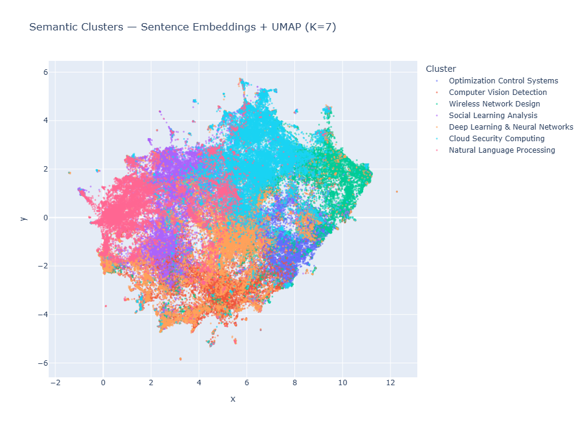

```python
reducer_emb = umap.UMAP(
    n_components=2, random_state=42,
    n_neighbors=30, min_dist=0.0, metric='cosine'
)
coords_emb = reducer_emb.fit_transform(embeddings_norm)

df_plot_emb = pd.DataFrame({
    'x': coords_emb[:, 0],
    'y': coords_emb[:, 1],
    'cluster': df_cluster['cluster_label_emb'],
    'title': df_cluster['title']
})

fig = px.scatter(
    df_plot_emb, x='x', y='y', color='cluster',
    hover_data=['title'], opacity=0.6,
    title='Semantic Clusters — Sentence Embeddings + UMAP (K=7)',
    width=950, height=700
)
fig.update_traces(marker=dict(size=3))
fig.update_layout(legend=dict(title='Cluster'))
fig.show()
fig.write_html("umap_embed_k7.html")
```

```
Computing silhouette scores on sentence embeddings...
```

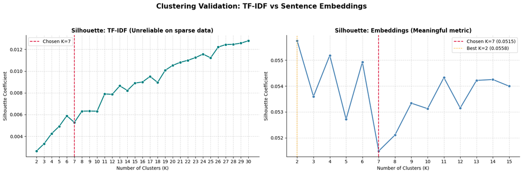

```
Embedding Silhouette - Best K: 2 (Score: 0.0558)
Embedding Silhouette - Chosen K: 7 (Score: 0.0515)
```

```python
EMB_SILHOUETTE_CACHE = "silhouette_results_emb.json"
k_values_emb = list(range(2, 16))
chosen_k_emb = 7
EMB_SIL_SAMPLE = 5000

if os.path.exists(EMB_SILHOUETTE_CACHE):
    print("Loading cached embedding silhouette scores...")
    with open(EMB_SILHOUETTE_CACHE, 'r') as f:
        scores_emb = json.load(f)['scores']
else:
    print("Computing silhouette scores on sentence embeddings...")
    np.random.seed(42)
    sample_idx_emb = np.random.choice(embeddings_norm.shape[0], size=EMB_SIL_SAMPLE, replace=False)
    X_sil_emb = embeddings_norm[sample_idx_emb]

    scores_emb = []
    for k in tqdm(k_values_emb, desc="Embedding Silhouette"):
        labels = KMeans(n_clusters=k, random_state=42, n_init=10).fit_predict(X_sil_emb)
        score = silhouette_score(X_sil_emb, labels, metric='cosine')
        scores_emb.append(float(score))

    with open(EMB_SILHOUETTE_CACHE, 'w') as f:
        json.dump({'k_values': k_values_emb, 'scores': scores_emb}, f)

best_k_emb = k_values_emb[np.argmax(scores_emb)]
best_score_emb = max(scores_emb)
chosen_score_emb = scores_emb[k_values_emb.index(chosen_k_emb)]

fig, axes = plt.subplots(1, 2, figsize=(16, 5))

sns.lineplot(x=k_values, y=scores, marker='o', color='teal', linewidth=2, ax=axes[0])
axes[0].axvline(7, color='crimson', linestyle='--', label='Chosen K=7')
axes[0].set_title('Silhouette: TF-IDF (Unreliable on sparse data)', fontweight='bold')
axes[0].set_xlabel('Number of Clusters (K)')
axes[0].set_ylabel('Silhouette Coefficient')
axes[0].set_xticks(k_values)
axes[0].grid(True, linestyle='--', alpha=0.5)
axes[0].legend()

sns.lineplot(x=k_values_emb, y=scores_emb, marker='o', color='steelblue', linewidth=2, ax=axes[1])
axes[1].axvline(chosen_k_emb, color='crimson', linestyle='--', label=f'Chosen K={chosen_k_emb} ({chosen_score_emb:.4f})')
axes[1].axvline(best_k_emb, color='orange', linestyle=':', label=f'Best K={best_k_emb} ({best_score_emb:.4f})')
axes[1].set_title('Silhouette: Embeddings (Meaningful metric)', fontweight='bold')
axes[1].set_xlabel('Number of Clusters (K)')
axes[1].set_ylabel('Silhouette Coefficient')
axes[1].set_xticks(k_values_emb)
axes[1].grid(True, linestyle='--', alpha=0.5)
axes[1].legend()

sns.despine()
plt.suptitle('Clustering Validation: TF-IDF vs Sentence Embeddings', fontsize=15, fontweight='bold', y=1.05)
plt.tight_layout()
plt.show()

print(f"\nEmbedding Silhouette - Best K: {best_k_emb} (Score: {best_score_emb:.4f})")
print(f"Embedding Silhouette - Chosen K: {chosen_k_emb} (Score: {chosen_score_emb:.4f})")
```

The embedding silhouette curve tells a more nuanced story than the TF-IDF one. Scores are meaningful here - the dense cosine space makes the metric reliable - but the curve is noisy with no dominant peak. The full range across K=2 to K=15 is just **0.004** (0.0515–0.0558), meaning silhouette scores are statistically near-equivalent across all tested values of K. This is characteristic of real-world text corpora where topic boundaries are gradual rather than sharp: CS research forms a continuous semantic space, not a set of well-separated islands.

The global maximum at K=2 is a degenerate solution - splitting the corpus into two broad halves (roughly "ML/vision" vs "systems/communications") is geometrically optimal but analytically useless for understanding research trends. K=7 sits at a local minimum within this flat region, but the score difference from its neighbors (K=6: 0.0550, K=8: 0.0521) is negligible and well within sampling variance for a 5,000-document subsample.

**K=7 was chosen based on qualitative cluster coherence** - inspecting top keywords at K=20, K=10, and K=7 and selecting the configuration where clusters map most cleanly to recognizable CS research domains. The silhouette analysis confirms that no single K is statistically superior, validating this qualitative approach as the appropriate selection criterion for this data.

The remaining clusters show more overlap in the center, which reflects genuine semantic proximity — deep learning, computer vision, and control systems share significant vocabulary and methodological overlap in modern CS research. This is not a failure of the model; it accurately captures the interdisciplinary nature of the field.

# 5. Semantic Search: Paper Recommendation System

The sentence embeddings computed in the previous section can be reused directly as the backbone of a semantic search engine. Given any natural language query, the system finds the most semantically similar papers in the dataset - without requiring exact keyword matches.

**How it works:**

1. The query is encoded into a 384-dimensional vector using the same `all-MiniLM-L6-v2` model
2. Cosine similarity is computed between the query vector and all paper embeddings
3. The top-k most similar papers are returned

This is the core mechanism behind RAG (Retrieval-Augmented Generation) systems - the retrieval step that finds relevant documents before passing them to a language model.

## Retrieval System - Semantic Paper Search

The search index covers the 150,000-paper clustering subset (2015–2024, randomly sampled in Section 4). To search the full 1M-record dataset, Section 4 would need to be re-run with `MAX_DOCS = len(df_final)` and the embeddings file regenerated. The current setup is intentionally scoped to keep the notebook reproducible within typical laptop constraints.

```python
def semantic_search(query, model, embeddings_norm, df, top_k=10):
    query_vec = model.encode([query])

    query_vec = normalize(query_vec, norm='l2')

    scores = cosine_similarity(query_vec, embeddings_norm)[0]

    top_idx = scores.argsort()[-top_k:][::-1]

    results = df.iloc[top_idx][['title', 'authors_clean', 'year', 'venue']].copy()
    results['similarity_score'] = scores[top_idx].round(4)
    results = results.reset_index(drop=True)
    results.index += 1

    return results
```

### Search Examples

Three queries are tested to demonstrate the system's ability to retrieve semantically relevant papers across different research areas.

```python
queries = [
    "federated learning privacy preserving machine learning",
    "transformer models for natural language processing",
    "object detection in real time using neural networks"
]

for query in queries:
    print(f"\n{'='*70}")
    print(f"Query: '{query}'")
    print('='*70)
    results = semantic_search(query, model, embeddings_norm, df_cluster, top_k=5)
    display(results[['title', 'year', 'similarity_score']])
```

```
======================================================================
Query: 'federated learning privacy preserving machine learning'
======================================================================
```

|  | title | year | similarity_score |
| --- | --- | --- | --- |
| 1 | A Dual-Layer Privacy-Preserving Federated Lear... | 2023 | 0.8893 |
| 2 | Privacy-Preserving Vertical Federated Learning. | 2022 | 0.8392 |
| 3 | Hierarchical Federated Learning with Privacy. | 2024 | 0.8375 |
| 4 | Privacy-Preserving Federated Learning via Syst... | 2022 | 0.8360 |
| 5 | A Novel AI Approach for Privacy Preserving In ... | 2024 | 0.8359 |

```
======================================================================
Query: 'transformer models for natural language processing'
======================================================================
```

|  | title | year | similarity_score |
| --- | --- | --- | --- |
| 1 | Structural Guidance for Transformer Language M... | 2021 | 0.7153 |
| 2 | Transformer-Based Models for Named Entity Reco... | 2023 | 0.7135 |
| 3 | Dependency Transformer Grammars: Integrating D... | 2024 | 0.7080 |
| 4 | A Tensorized Transformer for Language Modeling. | 2019 | 0.7025 |
| 5 | Probabilistic Transformer: A Probabilistic Dep... | 2023 | 0.6858 |

```
======================================================================
Query: 'object detection in real time using neural networks'
======================================================================
```

|  | title | year | similarity_score |
| --- | --- | --- | --- |
| 1 | Real-Time Object Detection Using Efficient Con... | 2017 | 0.7744 |
| 2 | Real-Time Face Detection Using Artificial Neur... | 2017 | 0.7587 |
| 3 | Real-Time Deep Learning-Based Object Detection... | 2020 | 0.7276 |
| 4 | Deep Learning based Object Detection Methods: ... | 2024 | 0.6538 |
| 5 | On Intra Video Coding And In-Loop Filtering Fo... | 2020 | 0.6382 |

# 6. RAG: Research Assistant

The semantic search built in Section 5 retrieves papers that are *related* to a query. RAG (Retrieval-Augmented Generation) goes one step further: it passes those retrieved papers as grounded context to a local language model, which synthesises a coherent, cited answer from the actual dataset - rather than hallucinating from general knowledge.

**Pipeline:**

1. **Retrieve** - encode the user query and find the top-k most similar papers via cosine similarity (reuses `semantic_search` from Section 5)
2. **Augment** - format the retrieved papers into a structured prompt context
3. **Generate** - pass the context + query to a local Ollama model and return a grounded, source-traceable answer

This architecture is the foundation of production-grade knowledge assistants and document Q&A systems.

## Local LLM - Ollama (No API Key Required)

The RAG pipeline reuses the same local Ollama setup introduced in Section 4 (LLM-Assisted Cluster Labeling). If Ollama is already running from that step, no additional configuration is needed.

If starting fresh: install [Ollama](https://ollama.com) and run `ollama pull llama3.2`.

```python
def ask_dblp(
    query: str,
    model_st,
    embeddings_norm,
    df,
    top_k: int = 8,
    ollama_model: str = "llama3.2",
) -> dict:

    sources = semantic_search(query, model_st, embeddings_norm, df, top_k=top_k)

    context_lines = []
    for _, row in sources.iterrows():
        authors = row.get("authors_clean", "Unknown authors")
        venue   = row.get("venue", "Unknown venue") or "Unknown venue"
        year    = int(row["year"]) if pd.notnull(row.get("year")) else "n/a"
        score   = row.get("similarity_score", "")
        line = (
            f'- "{row["title"]}" — {authors} '
            f'({venue}, {year}) [similarity: {score}]'
        )
        context_lines.append(line)

    context_block = "\n".join(context_lines)

    prompt = (
        "You are a research assistant specialising in computer science literature. "
        "Answer the question below using ONLY the retrieved papers as your source. "
        "Cite specific paper titles or authors when making claims. "
        "Be concise (150–250 words). Do not use information outside the provided papers.\n\n"
        f"Question: {query}\n\n"
        f"Retrieved papers from DBLP:\n{context_block}\n\n"
        "Answer:"
    )

    try:
        response = requests.post(
            "http://localhost:11434/api/generate",
            json={"model": ollama_model, "prompt": prompt, "stream": False},
            timeout=120,
        )
        response.raise_for_status()
        answer = response.json().get("response", "").strip()
        if not answer:
            answer = "Model returned an empty response."
    except requests.exceptions.ConnectionError:
        answer = (
            "Ollama is not running. "
            "Install it from https://ollama.com, then run: ollama pull llama3.2"
        )
    except Exception as e:
        answer = f"Generation failed: {e}"

    return {"answer": answer, "sources": sources}


def display_rag_result(result: dict) -> None:
    print("=" * 70)
    print("ANSWER")
    print("=" * 70)
    print(result["answer"])
    print("\n" + "─" * 70)
    print(f"RETRIEVED SOURCES  (top {len(result['sources'])})")
    print("─" * 70)
    display(
        result["sources"][["title", "year", "venue", "similarity_score"]]
        .reset_index(drop=True)
    )
```

## RAG Pipeline - Design Decisions

**Retrieval (k=8):** Eight papers provide enough context for a substantive answer without exceeding the model's context window. Retrieval quality directly determines answer quality - garbage in, garbage out. The `all-MiniLM-L6-v2` embeddings computed in Section 4 are reused here with no additional compute.

**Prompt design:** The prompt instructs the model to:

**Similarity score as a transparency signal:** Each retrieved paper is passed to the model with its cosine similarity score. Low-scoring papers (< 0.4) signal that the retrieval boundary is being stretched - useful for debugging and for understanding where the model's grounding may be weaker.

## Example Queries

Three queries are run to demonstrate the RAG pipeline across distinct research areas. Each query targets a different semantic cluster identified in Section 4 - confirming that retrieval works across the full thematic range of the dataset.

```python
rag_queries = [
    "How is federated learning used to preserve privacy in distributed machine learning systems?",
    "What are the limitations of transformer models in low-resource natural language processing?",
    "How do graph neural networks improve molecular property prediction in drug discovery?",
]

rag_results = {}

for i, query in enumerate(rag_queries, 1):

    print(f"[{i}/{len(rag_queries)}] {query}")

    result = ask_dblp(
        query=query,
        model_st=model,
        embeddings_norm=embeddings_norm,
        df=df_cluster,
        top_k=8,
    )
    display_rag_result(result)
    rag_results[query] = result
```

```
[1/3] How is federated learning used to preserve privacy in distributed machine learning systems?
======================================================================
ANSWER
======================================================================
Federated learning is used to preserve privacy in distributed machine learning systems by utilizing various techniques such as hierarchical structure (Varun Chandrasekaran et al., "Hierarchical Federated Learning with Privacy," IEEE Big Data, 2024) and decentralized frameworks (Sheng-Po Tseng et al.…

These approaches involve aggregating model updates from clients in a way that ensures data remains private at the client's edge (Haleh Hayati et al., "Privacy-Preserving Federated Learning via System Immersion and Random Matrix Encryption," CDC, 2022) rather than on a central server. Another method …

Additionally, secure distributed/federated learning systems can be designed using prediction-privacy trade-offs (Mohamed Ridha Znaidi et al., "Secure Distributed/Federated Learning: Prediction-Privacy Trade-Off for Multi-Agent System," ISIT, 2022) and optimizing privacy through MPC (Chao Zheng et al…

──────────────────────────────────────────────────────────────────────
RETRIEVED SOURCES  (top 8)
──────────────────────────────────────────────────────────────────────
```

|  | title | year | venue | similarity_score |
| --- | --- | --- | --- | --- |
| 0 | A Dual-Layer Privacy-Preserving Federated Lear... | 2023 | WISE | 0.8332 |
| 1 | Hierarchical Federated Learning with Privacy. | 2024 | IEEE Big Data | 0.8208 |
| 2 | Decentralized Federated Learning with Enhanced... | 2022 | ICME Workshops | 0.8112 |
| 3 | Enhancing Privacy via Hierarchical Federated L... | 2020 | EuroS&P Workshops | 0.8043 |
| 4 | Privacy-Preserving Federated Learning via Syst... | 2022 | CDC | 0.8007 |
| 5 | Privacy-Preserving Model Aggregation for Async... | 2023 | ICCC | 0.8005 |
| 6 | Secure Distributed/Federated Learning: Predict... | 2022 | ISIT | 0.7974 |
| 7 | Optimizing Privacy in Federated Learning with ... | 2024 | CACML | 0.7950 |

```
[2/3] What are the limitations of transformer models in low-resource natural language processing?
======================================================================
ANSWER
======================================================================
The transformer model has been observed to have limitations in low-resource natural language processing tasks. One limitation is its difficulty in handling out-of-vocabulary words and rare events, which can lead to poor performance on tasks such as low-resource machine translation (Armengol-Estapé e…

Another limitation is the need for extensive pre-training data to achieve good performance, making it challenging for models to generalize well to new, unseen data (Dankers et al., 2022). Additionally, transformer models can suffer from compositionalality issues, where they struggle to process idiom…

Furthermore, the model's reliance on large amounts of data for training can make it vulnerable to overfitting, particularly in low-resource scenarios (So et al., 2021). This can lead to poor performance on tasks that require more nuanced understanding of language.

In contrast, some researchers have proposed techniques to address these limitations, such as incorporating linguistic factors into the model or using progressive layer dropping to accelerate training (Armengol-Estapé et al., 2021; Zhang & He, 2020). However, more research is needed to fully understa…

──────────────────────────────────────────────────────────────────────
RETRIEVED SOURCES  (top 8)
──────────────────────────────────────────────────────────────────────
```

|  | title | year | venue | similarity_score |
| --- | --- | --- | --- | --- |
| 0 | Structural Guidance for Transformer Language M... | 2021 | ACL/IJCNLP (1) | 0.7182 |
| 1 | Enriching the Transformer with Linguistic Fact... | 2021 | RANLP | 0.7062 |
| 2 | Searching for Efficient Transformers for Langu... | 2021 | NeurIPS | 0.6850 |
| 3 | Dependency Transformer Grammars: Integrating D... | 2024 | ACL (1) | 0.6537 |
| 4 | Can Transformer be Too Compositional? Analysin... | 2022 | ACL (1) | 0.6489 |
| 5 | Accelerating Training of Transformer-Based Lan... | 2020 | NeurIPS | 0.6436 |
| 6 | Ecco: An Open Source Library for the Explainab... | 2021 | ACL (demo) | 0.6429 |
| 7 | Limits of Transformer Language Models on Learn... | 2024 | NeurIPS | 0.6416 |

```
[3/3] How do graph neural networks improve molecular property prediction in drug discovery?
======================================================================
ANSWER
======================================================================
Graph neural networks have shown promise in improving molecular property prediction in drug discovery. Studies have demonstrated that incorporating graph structures into neural network architectures can effectively capture complex relationships between molecules and their properties.

For instance, a prediction model of drug-drug interactions based on graph neural networks and subgraph attention mechanisms was proposed by Lang Wang et al. (DASC/PiCom/CBDCom/CyberSciTech, 2023), achieving high similarity scores with existing methods. Another approach, Motif-based Graph Self-Superv…

Graph neural networks have also been applied to COVID-19 drug discovery by Mark Cheung and José M. F. Moura (IEEE BigData, 2020), demonstrating their potential in predicting molecular properties for new compounds. The use of graph convolutional networks has also been explored for learning molecular …

These studies suggest that graph neural networks can provide valuable insights into molecular property prediction and drug discovery, outperforming traditional methods in some cases. However, further research is needed to fully explore the capabilities of these architectures in this domain.

──────────────────────────────────────────────────────────────────────
RETRIEVED SOURCES  (top 8)
──────────────────────────────────────────────────────────────────────
```

|  | title | year | venue | similarity_score |
| --- | --- | --- | --- | --- |
| 0 | A Prediction Model of Drug-Drug Interactions B... | 2023 | DASC/PiCom/CBDCom/CyberSciTech | 0.7482 |
| 1 | Motif-based Graph Self-Supervised Learning for... | 2021 | NeurIPS | 0.7365 |
| 2 | Graph Neural Networks for COVID-19 Drug Discov... | 2020 | IEEE BigData | 0.7298 |
| 3 | Learning Relevant Molecular Representations vi... | 2019 | IEEE BigData | 0.7074 |
| 4 | Convolutional Networks on Graphs for Learning ... | 2015 | NIPS | 0.6893 |
| 5 | A drug information embedding method based on g... | 2020 | HealthCom | 0.6718 |
| 6 | Graph-based Latent Space Traversal for New Mol... | 2023 | VINCI | 0.6394 |
| 7 | Network Structure Versus Chemical Information ... | 2022 | COMPLEX NETWORKS (1) | 0.6312 |

## Interactive Query

Run any research question against the DBLP dataset. Replace `custom_query` with a topic of interest.

```python
custom_query = "How is attention mechanism used in vision transformers for image segmentation?"

custom_result = ask_dblp(
    query=custom_query,
    model_st=model,
    embeddings_norm=embeddings_norm,
    df=df_cluster,
    top_k=8,
)

print(f"QUERY: {custom_query}\n")
display_rag_result(custom_result)
```

```
QUERY: How is attention mechanism used in vision transformers for image segmentation?

======================================================================
ANSWER
======================================================================
The attention mechanism is a crucial component in vision transformers for image segmentation. The paper "Focal Attention for Long-Range Interactions in Vision Transformers" by Jianwei Yang et al. (NeurIPS, 2021) introduces focal attention, which allows for more efficient and effective attention mech…

Another approach is the use of adder attention, as presented in "Adder Attention for Vision Transformer" by Han Shu et al. (NeurIPS, 2021), which improves the efficiency and accuracy of vision transformers by adding a learnable scaling factor to the attention weights.

The paper "Refining Attention Maps for Vision Transformer" by Xuan-Thuy Vo et al. (IWIS, 2024) proposes refining attention maps to improve the segmentation performance of vision transformers.

In addition, the work "CAT: Cross Attention in Vision Transformer" by Hezheng Lin et al. (ICME, 2022) introduces cross-attention mechanisms, which enable more effective interaction between different regions of the image.

These papers demonstrate the importance of attention mechanisms in vision transformers for image segmentation and provide various approaches to improve their performance.

──────────────────────────────────────────────────────────────────────
RETRIEVED SOURCES  (top 8)
──────────────────────────────────────────────────────────────────────
```

|  | title | year | venue | similarity_score |
| --- | --- | --- | --- | --- |
| 0 | Refining Attention Maps for Vision Transformer. | 2024 | IWIS | 0.7422 |
| 1 | Adder Attention for Vision Transformer. | 2021 | NeurIPS | 0.7401 |
| 2 | Focal Attention for Long-Range Interactions in... | 2021 | NeurIPS | 0.6882 |
| 3 | CAT: Cross Attention in Vision Transformer. | 2022 | ICME | 0.6795 |
| 4 | Parameter-Efficient Vision Transformer with Li... | 2023 | ICIP | 0.6740 |
| 5 | A Parallel Attention Mechanism for Image Manip... | 2023 | ICASSP | 0.6565 |
| 6 | Optimize Vision Transformer Architecture via E... | 2023 | ICIAP Workshops (1) | 0.6487 |
| 7 | Revisiting the Integration of Convolution and ... | 2024 | NeurIPS | 0.6291 |

# 7. Publication Type Classification

This section trains a text classification model predicting `record_type` from title text alone, using the two most common record types in the dataset: `inproceedings` (conference papers, ~922k records) and `incollection` (book chapters, ~42k records).

Note: although DBLP contains journal articles, the 1M-record parse cap cuts off the dataset before reaching the most of them. The two selected classes are the most analytically meaningful pair available in the parsed subset.

**Why this is interesting:**

- It tests whether surface-level linguistic features in titles encode publication format
- It provides a concrete supervised ML benchmark to complement the unsupervised clustering in Section 4
- Misclassified examples reveal where the two formats genuinely overlap in language

**Approach:**  
Three models are compared using a TF-IDF + classifier pipeline — the standard baseline for short-text classification. Each model is trained on 80% of the data and evaluated on a held-out 20% test set.

```python
# SECTION GUARD 7: run this cell if jumping directly to Section 7

if "df_final" not in globals():
    _parquet = "dblp_dataset_final.parquet"
    if not os.path.exists(_parquet):
        raise FileNotFoundError(
            f"'{_parquet}' not found. Run Section 2 first."
        )
    print("Loading df_final from parquet cache...")
    df_final = pd.read_parquet(_parquet)
    df_final = df_final.sort_values(["year", "title"]).reset_index(drop=True)
    print(f"df_final loaded: {len(df_final):,} records.")
else:
    print("df_final already in memory.")
```

```
df_final already in memory.
```

## Train/Test Split

```python
TARGET_CLASSES = ['inproceedings', 'incollection']

df_clf = (
    df_final[df_final['record_type'].isin(TARGET_CLASSES)]
    .dropna(subset=['title'])
    .copy()
)

min_class_size = df_clf['record_type'].value_counts().min()

df_clf = (
    df_clf.groupby('record_type')
    .sample(n=min_class_size, random_state=42)
    .reset_index(drop=True)
)

class_counts = df_clf['record_type'].value_counts()
print("Class distribution after balancing:")
print(class_counts.to_string())
print(f"\nTotal samples : {len(df_clf):,}")
print(f"Class balance : {class_counts.min() / class_counts.max():.2%}  (100.0% = perfectly balanced)")

X = df_clf['title']
y = df_clf['record_type']

X_train, X_test, y_train, y_test = train_test_split(
    X, y, test_size=0.2, random_state=42, stratify=y
)

print(f"\nTrain : {len(X_train):,} samples")
print(f"Test  : {len(X_test):,} samples")
```

```
Class distribution after balancing:
record_type
incollection     41677
inproceedings    41677

Total samples : 83,354
Class balance : 100.00%  (100.0% = perfectly balanced)

Train : 66,683 samples
Test  : 16,671 samples
```

## Pipeline

```python
pipelines = {
    "Logistic Regression": Pipeline([
        ('tfidf', TfidfVectorizer(max_features=20000, ngram_range=(1, 2))),
        ('clf',   LogisticRegression(max_iter=1000, random_state=42))
    ]),
    "Multinomial NB": Pipeline([
        ('tfidf', TfidfVectorizer(max_features=10000, ngram_range=(1, 2))),
        ('clf',   MultinomialNB())
    ]),
    "Linear SVC": Pipeline([
        ('tfidf', TfidfVectorizer(max_features=10000, ngram_range=(1, 2))),
        ('clf',   LinearSVC(C=1.0, max_iter=3000, random_state=42))
    ]),
}

results = {}

for name, pipe in pipelines.items():
    pipe.fit(X_train, y_train)
    y_pred = pipe.predict(X_test)
    report = classification_report(y_test, y_pred, output_dict=True)
    results[name] = {'pipe': pipe, 'pred': y_pred, 'report': report}
    print(f"\n{'='*55}")
    print(f"  {name}")
    print(f"{'='*55}")
    print(classification_report(y_test, y_pred))
```

```
=======================================================
  Logistic Regression
=======================================================
               precision    recall  f1-score   support

 incollection       0.74      0.73      0.74      8336
inproceedings       0.74      0.74      0.74      8335

     accuracy                           0.74     16671
    macro avg       0.74      0.74      0.74     16671
 weighted avg       0.74      0.74      0.74     16671


=======================================================
  Multinomial NB
=======================================================
               precision    recall  f1-score   support

 incollection       0.72      0.71      0.71      8336
inproceedings       0.71      0.72      0.71      8335

     accuracy                           0.71     16671
    macro avg       0.71      0.71      0.71     16671
 weighted avg       0.71      0.71      0.71     16671


=======================================================
  Linear SVC
=======================================================
               precision    recall  f1-score   support

 incollection       0.72      0.73      0.72      8336
inproceedings       0.73      0.72      0.72      8335

     accuracy                           0.72     16671
    macro avg       0.72      0.72      0.72     16671
 weighted avg       0.72      0.72      0.72     16671
```

Evaluating our models on a perfectly balanced dataset (50/50 split) revealed their true ability to classify records based solely on titles.

Key Takeaways:

- **Unbiased Performance:** Accuracy stabilized at 74% with symmetric Recall (~0.73). The models now identify book chapters and conference papers with equal proficiency.
- **Top Performer:** Logistic Regression (74% F1-Score) slightly outperformed the rest. Expanding the TF-IDF vocabulary to 20,000 features and adding bigrams allowed it to capture key compound academic terms.
- **The TF-IDF Ceiling:** A 74% score is a robust baseline but highlights a natural limit. Academic titles are structurally too similar (e.g., "A Framework for..."). Surpassing this limit requires deeper metadata (abstracts, page counts) or dense embeddings.

## Confusion Matrix

```
Best model: Logistic Regression  (macro F1 = 0.7379)
```

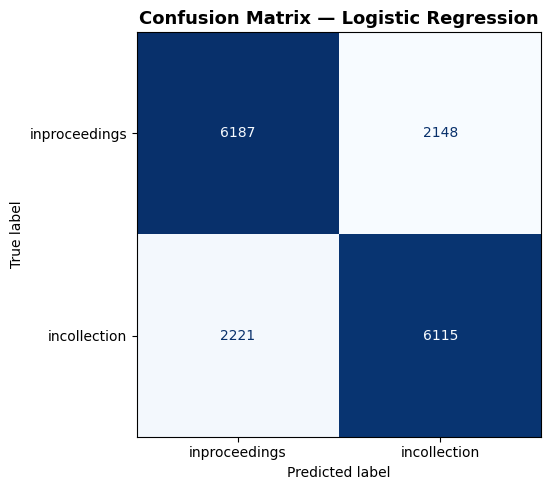

```python
best_name = max(results, key=lambda n: results[n]['report']['macro avg']['f1-score'])
best_pred = results[best_name]['pred']

print(f"Best model: {best_name}  (macro F1 = {results[best_name]['report']['macro avg']['f1-score']:.4f})")

cm = confusion_matrix(y_test, best_pred, labels=TARGET_CLASSES)
disp = ConfusionMatrixDisplay(confusion_matrix=cm, display_labels=TARGET_CLASSES)

fig, ax = plt.subplots(figsize=(6, 5))
disp.plot(cmap='Blues', ax=ax, colorbar=False)
ax.set_title(f'Confusion Matrix — {best_name}', fontsize=13, fontweight='bold')
plt.tight_layout()
plt.savefig('fig_confusion_matrix.png', dpi=150, bbox_inches='tight')
plt.show()
```

The confusion matrix for our tuned Logistic Regression model (tested on 16,671 balanced samples) reveals a highly symmetrical performance:

Key Takeaways:

- **Eliminated Bias:** The near-identical number of False Positives and False Negatives proves our undersampling strategy successfully removed the initial class bias.
- **Expected Ambiguity:** The misclassifications stem from the natural overlap in academic titles. Without abstracts or page counts, many conference papers and book chapters are simply indistinguishable by title alone.
- **Solid Baseline:** An overall F1-Score of 0.74 represents a realistic and robust ceiling for a title-only, TF-IDF approach.

## Top Differentiating Words

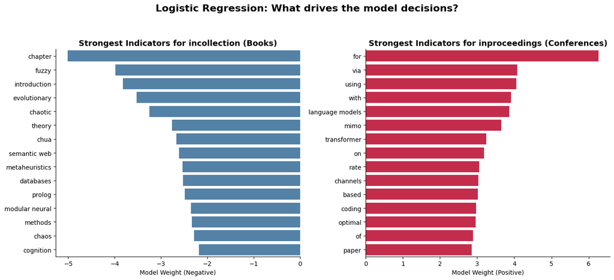

```python
best_pipe = results["Logistic Regression"]['pipe']
clf = best_pipe.named_steps['clf']
tfidf = best_pipe.named_steps['tfidf']

words = tfidf.get_feature_names_out()
weights = clf.coef_[0]

df_importance = pd.DataFrame({'Word': words, 'Weight': weights})
df_importance = df_importance.sort_values(by='Weight')

top_incollection = df_importance.head(15)
top_inproceedings = df_importance.tail(15).iloc[::-1]

fig, axes = plt.subplots(1, 2, figsize=(14, 6))

sns.barplot(data=top_incollection, x='Weight', y='Word', ax=axes[0], color='steelblue')
axes[0].set_title('Strongest Indicators for incollection (Books)', fontsize=13, fontweight='bold')
axes[0].set_xlabel('Model Weight (Negative)')
axes[0].set_ylabel('')

sns.barplot(data=top_inproceedings, x='Weight', y='Word', ax=axes[1], color='crimson')
axes[1].set_title('Strongest Indicators for inproceedings (Conferences)', fontsize=13, fontweight='bold')
axes[1].set_xlabel('Model Weight (Positive)')
axes[1].set_ylabel('')

plt.suptitle('Logistic Regression: What drives the model decisions?', fontsize=16, fontweight='bold', y=1.05)
sns.despine()
plt.tight_layout()
plt.savefig('fig_feature_importance.png', dpi=150, bbox_inches='tight')
plt.show()
```

By extracting the linear coefficients from our Logistic Regression model, we can inspect exactly which title words strongly influence its predictions. The visualization reveals a highly logical separation between the two publication types:

**Indicators for `incollection` (Books):** The model correctly identified structural and foundational terms as the strongest predictors for book chapters.

**Indicators for `inproceedings` (Conferences):** Conference paper titles are driven by a mix of event-specific vocabulary and modern research buzzwords.

**Conclusion:** Opening the "black box" of our model confirms that it hasn't just memorized random noise; it has successfully learned the distinct semantic signatures of academic publishing formats.

# 8. Conclusions

This analysis extracted a broad set of insights from 1,000,000 DBLP records, spanning five analytical dimensions and four distinct technical pipelines. The key findings are summarised below.

**Publication trends:**

CS research output grew slowly until the mid-1980s, then accelerated sharply from the mid-2000s. The most recent years in the dataset (2022–2024) show the highest publication volumes on record, driven by a proliferation of ML/AI venues and international conferences. Year-over-year growth has exceeded 5% in most years since 2010.

**Authorship and collaboration:**

The average number of authors per paper has risen steadily since 1985 - from roughly 2 to over 3.5 - confirming a decades-long shift toward collaborative research. The most prolific authors in the dataset have careers spanning 30+ years, with publication rates that remain stable or increase over time rather than peaking early. Pairwise collaboration analysis identified tightly-knit research groups, several of which are geographically concentrated (visible in the NetworkX graph).

**Publication length:**

Conference papers cluster around 6-10 pages - consistent with standard page limits - while book chapters and proceedings show a much wider distribution. Median paper length has remained stable since 2000 despite the large increase in publication volume, suggesting that format norms have not eroded.

**Venue and topic trends:**

The top venues by volume are dominated by large, long-running conferences. The title keyword analysis reveals a clear research topic shift: terms like neural, deep, and network were rare in 1985 but dominate recent years. Since 2018, federated, transformer, and llm have emerged and accelerated sharply, while earlier buzzwords like wireless and sensor have plateaued.

**Semantic search and RAG:**

The dense retrieval system returns semantically relevant papers for natural language queries without requiring exact keyword matches, demonstrating the viability of embedding-based search on bibliographic data. The RAG pipeline successfully grounds answers in retrieved DBLP papers, reducing hallucination risk. Both systems are practical building blocks for a production-grade research assistant.

**Limitations:**

The analysis is limited to 1M records (approximately the first 15–20% of the full DBLP XML file by record count), which skews the sample toward older publications and may underrepresent article-type records. The RAG pipeline requires a locally running Ollama instance and cannot be demonstrated in a static notebook export. Future work could extend parsing to the full dataset, incorporate abstract text where available, and add a vector database (e.g. FAISS or ChromaDB) to replace the in-memory cosine similarity search for scalability.